# Hotel Recommender Analysis Report

Chia Yue Zhu Ameline, (A0211277L)

Kho Bee Yen Kris, (A0177966E)

Liu Meng Chuan, (A0211313A)

Wong Kwok Cheong, (A0211279H)

13 Nov, 2022

### INTRODUCTION

Over the years, staycations have been growing in popularity among Singaporeans. With all the information and data present on booking platforms, analytics can be used as a key tool to attain analytical insights and make new data-driven discoveries. Hence for this project, we have explored and extracted data from an online traveling platform, Trip.com. From this, our analysis have uncover insights such as

1. Hotel attributes that attracts booking
2. Driving factors determining hotel prices
3. Guest type and their booking behavior

In addition to our analysis, we also explored the idea of recommending and suggesting suitable hotels to guests based on booking behaviors. With our analysis and analytical models, we hope to understand the hotel industry better and propose solutions to increase productivity, efficiency, and profitability for businesses.

### BUSINESS DOMAIN AND DATA

Trip.com is an international online traveling platform that provides booking services for flights, hotels, trains, car rentals, airport transfers, and tours and attraction tickets globally. The site offers more than 1.2 million hotels in 200 countries and regions, as well as over 2 million flight routes connecting more than 5,000 cities. Thus, Trip.com contains a wide range of data related to various sub industry within the hospitality industry. As part of the project, we will be focusing our analysis on hotels within Singapore. With more than 500 hotels in Singapore, we have managed to mined more than 200 unique hotels and its relevant data. The data collected are:

**Hotel Information Data**

This dataset contains general information related to all 203 mined hotels in Singapore. It includes columns such as:

- **star:** An indicator that denotes the hotel’s quality, cleanliness and standards. Eg: 1 star, 2 star, 3 star, 4 star, and 5 star (Numeric value)
- **hotelName:** The name of the hotel (Character value)
- **hotelId:** The ID that uniquely identify the hotel within Trip.com (Numeric value)
- **location:** The location where the hotel is located at (Character value)
- **freeCancelTag:** An indicator that denotes if the hotel provides free cancellation policies. Eg. “Free Cancellation” or “NA” (Character value)
- **favorityCountMsg:** The count of guests who favorites or saves the hotel (Character value)
- **score:** Similar to Hotel Star Rating, its a more precise indicator that denotes the hotel’s quality, cleanliness and standards (Numeric value)
- **scoreDescription:** A descriptive term that describe the Hotel Score Rating (Character value). The breakdown of the term is:
  - score < 4: “”
  - score >= 4 and score <= 4.2: “Very Good”
  - score >= 4.3 and score <= 4.5: “Excellent”
  - score >= 4.6 and score <= 4.8: “Outstanding”
  - score >= 4.9: “Perfect”
- **totalReviews** Total number of reviews given to the hotel (Character value)

**Hotel Amenities Data**

This dataset contains hotel amenities information related to all 203 mined hotels in Singapore. It includes columns such as:

- **HotelURL:** The relevant URL of each hotel within Trip.com (Character value)
- **HotelID:** The ID that uniquely identify the hotel within Trip.com (Numeric value)
- **HotelNames:** The name of the hotel (Character value)

The remaining columns indicate boolean values of amenities, services, or facilities the hotel have

**Hotel Price Data**

This dataset contains price information related to all 203 mined hotels in Singapore. It includes columns such as:

- **hotelId:** The ID that uniquely identify the hotel within Trip.com (Numeric value)
- **hotelName:** The name of the hotel (Character value)
- **pricePerNight:** Since there are multiple room types in a hotel, we have decided to take the cheapest room price. So this column will contain the hotel price of their cheapest room for a night’s stay (Numeric value)
- **checkInDate:** The check-in date of the mined price. We have mined a total of 365 nights for each hotel (Character value)
- **checkOutDate:** The check-out date of the mined price. We have mined a total of 365 nights for each hotel (Character value)

**Surrounding Places Of Interest Per Hotel Data**

This dataset contains places of interest surrounding each hotel of all 203 mined hotels in Singapore. It includes columns such as:

- **distance:** The distance of the place of interest from the hotel (Character value)
- **placeName:** The name of the place of interest (Character value)
- **distanceNumbert:** Similar to the distance column, its a more precise distance (calculated in meters) of the place of interest from the hotel (Numeric value)
- **hotelId:** The ID that uniquely identify the hotel within Trip.com (Numeric value)

**User Review Data**

This dataset contains user review of all 203 mined hotels in Singapore if there is. It includes columns such as:

- **hotelId:** The ID that uniquely identify the hotel within Trip.com (Numeric value)
- **userId:** The ID that uniquely identify the user who stayed in the hotel booked from Trip.com and wrote a review of it (Character value)
- **userId_cleaned:** Similar to the user ID, it is a cleaned user ID that uniquely identify the user who stayed in the hotel booked from Trip.com and wrote a review of it (Character value)
- **nickname:** The name of the user (Character value)
- **checkInDate:** The check-in date of the user (Character value)
- **content:** The review written by the user (Character value)
- **travelType:** The ID that uniquely identify the travel type of the users (Numeric value)
- **travelTypeText:** A descriptive term that describe the travel type of the users (Character value). The breakdown of the term is:
  - travel type = 0: “Other”
  - travel type = 10: “Business travellers”
  - travel type = 30: “Family”
  - travel type = 40: “Friends”
  - travel type = 50: “Solo travellers”
  - travel type = 60: “Booked for others”
  - travel type = 70: “Couples”
- **ratingAll:** The overall rating given by the user for the hotel (Numeric value)
- **ratingLocation:** The location rating given by the user for the hotel (Numeric value)
- **ratingFacility:** The facility rating given by the user for the hotel (Numeric value)
- **ratingService:** The service rating given by the user for the hotel (Numeric value)
- **ratingRoom:** The room rating given by the user for the hotel (Numeric value)
- **commentLevel:** A descriptive term that describe the overall rating given by the user for the hotel (Character value)
  - ratingAll < 4.5: “”
  - ratingAll = 4.5: “Good”
  - ratingAll = 4.7: “Outstanding”
  - ratingAll = 5: “Perfect”

### ANALYSIS PROCESS

After determining the choice of topic, we make use of the CRISP-DM framework to plan and guide the process of our project. Below are the steps we took for this project:

**STEP 01: Business Understanding**

As part of the business understanding phase, we dive into understanding what the business requires. To simplify the thinking process, we looked from an angle of a user by coming up with problems we faced as users while booking hotels in Singapore. Following that, we concluded that it is difficult to determine the best price of a hotel given that room prices fluctuates on a day to day basis. Consequently, “average” priced hotels tend to lose out to cheaper hotels as users will look for cheaper hotel alternatives. Thus, we made this issue our problem statement and we will like to figure solutions that could potentially help users and hotel businesses. After defining our problem statement, we started to look into the various types of analysis we will be doing. By sketching out visualization graphs and modelings ideas, we managed to understand the sort of data we will be requiring to execute our plan.

**STEP 02: Data Understanding**

Once we have a clear picture of what data we need, we created a documentation to understand the various field attributes to mine. Then we cluster relevant attributes together and document them into a table. By forming relationship between data, we managed to understand the types of field we are working with and how we can group similar data together to create our data frames. Once we have completed the data planning phase, we started the mining process. After mining data off Trip.com, we managed to populate all 5 data that are mentioned above. However, the data collected are not in good quality. Hence, we proceeded with the data preparation phase.

**STEP 03: Data Preparation**

As part of the data preparation phase, we started to clean the data by removing irrelevant values and cross checking the classes of each data column. By correcting, imputing, and removing erroneous values, we avoided the mistake of “garbage-in, garbage-out” analysis. In addition, we manipulated the mined data and constructed new columns that will assist with our analysis. Since our data was mined with respect to our documentation, we had to integrate tables together by combining 2 data frames into 1. By doing so, we have a more holistic data to work with for our analysis.

**STEP 04: Modeling**

After ensuring that our data are cleaned and proper, we started to build the various visualization and models we had plan during the business understanding phase. While we build the models, we evaluated and test the accuracy of our models by splitting the data into training, test, and validation sets so as to test the ability of the model to predict base on different data types

**STEP 05: Analysis/Evaluation**

Lastly, we evaluated the model and determined if the insights generated from the model meets the business. Based on that, we can draw conclusive insights that we can assess then propose solutions to increase productivity, efficiency, and profitability for businesses.

### DATA COLLECTION

For the mining process, we attempted 2 different methods of retrieving data from Trip.com. The methods are:

**API**

Mining using API is a relatively straightforward and fast approach of attaining data directly from the data source. Based on the transaction records that are stored in the system, we can instantly get loads of data by accessing the POST method then tapping into the return responses. Even though API is a convenient method to mine data, not all API are useful in providing us with relevant data. Thus, we had to determine the right API to tab into so that we can retrieve data that will be useful for our analysis. To determine the right API, we individually assess the inspect network activities and check if each response contains relevant data that we can use. Once we have determine that, we ran the API’s curl command of the request to check if the client server return the expected data. As each API call is unique to its respective hotels, we gathered a list of hotel Ids and iteratively call the APIs. Using this method, we have mined the following set of data:

1. Hotel Information Data
2. Hotel Price Data
3. Surrounding Places Of Interest Per Hotel Data
4. User Review Data

The codes are shown below:

- **Mining code for Hotel Information Data**

```r
library(ggplot2)
library(httr)
library(htm2txt)
library(jsonlite)
library(stringr)
library(tidyr)
library(writexl)
library(rvest)
library(readr)
library(dplyr)
library(lubridate)
library(readxl)
library(tm)
library(wordcloud)
library(RColorBrewer)
library(tm)
library(recommenderlab)
library(magrittr)
library(pander)

# Initialize an empty data frame
df_hotel_info <- data.frame(matrix(ncol=10, nrow=0))
cols <- c('star', 'hotelName','hotelId','location','freeCancelTag', 'favorityCountMsg','score','scoreDescription', 'totalReviews', 'topQuality')
colnames(df_hotel_info) <- cols

# Manually retrieve a list of hotel IDs and created a vector hotelIds
hotel_info_df <- read_excel("trip_com_HOTEL_ID.xlsx")
hotelIds <- as.vector(hotel_info_df$HOTEL_ID)

# New hotel ids -> MANAULLY factor in more locations
hotelIds2 <- c(712600, 56704737,7982267,996309, 687490)
head(hotelIds)
```

```
## [1]  998612  996055 3801236 2064004 1466284  991874
```

```r
# API call function to get the data from individual hotels (2022-10-26 to 2022-10-27)
apiCallNearbyHotel <- function(masterHotelId){
  res = POST(
    "https://sg.trip.com/restapi/soa2/16708/json/hotelSearchNearby?x-traceID=1658849562341.1pmnm5-1666016479066-1666203502",
    add_headers('authority = sg.trip.com'),
    add_headers('accept = application/json'),
    add_headers('accept-language = en-US,en;q=0.9'),
    add_headers('content-type = application/json;charset=UTF-8'),
    add_headers('cookie = ibu_home_language_match_union_flag=0; _abtest_userid=fb70a796-d789-4b0b-80d8-afdd54b85933; _gcl_au=1.1.562621262.1658849563; _RGUID=751c843f-5682-48a5-a9ff-1e84de692fb8; _RDG=281a5c31eaa24722803983fe33c78ee19f; _RSG=bYaWMz3XSK7u.IQUJe7_dA; _bfaStatusPVSend=1; ibu_online_home_language_match={"isFromTWNotZh" =false,"isFromIPRedirect" =false,"isFromLastVisited" =true,"isRedirect" =false,"isShowSuggestion" =false,"lastVisited" ="https =//sg.trip.com?locale=en-sg"}; cookiePricesDisplayed=SGD; _tp_search_latest_channel_name=hotels; _gid=GA1.2.1760276045.1663081390; _RF1=137.132.215.24; g_state={"i_p" =1663088594680,"i_l" =1}; ibu_h5_site=SG; ibu_h5_group=trip; ibu_h5_local=en-sg; ibu_h5_lang=ensg; ibu_h5_curr=SGD; IBU_TRANCE_LOG_URL=%2Fhotels%2Fsingapore-hotel-detail-996041%2Fparkroyal-on-beach-road-singapore%2F; librauuid=; _clck=5quac4|1|f4u|0; IBU_TRANCE_LOG_P=37682130973; hotel_h5_view_ids=%5B%22996041%22%5D; IBU_showtotalamt=1; ibu-h5-pop-hotel=0; ibu_online_permission_cls_ct=2; ibu_online_permission_cls_gap=1663082802191; hotelhst=1164390341; ibulanguage=SG; ibulocale=en_sg; intl_ht1=h4%3D73_687472%2C73_909897%2C73_994990%2C73_996041; _bfa=1.1658849562341.1pmnm5.1.1658849562341.1663083559409.2.32.10320668588; _bfs=1.18; _ubtstatus=%7B%22vid%22%3A%221658849562341.1pmnm5%22%2C%22sid%22%3A2%2C%22pvid%22%3A32%2C%22pid%22%3A10320668147%7D; hotel=687472; _ga=GA1.2.523270998.1658849562; _uetsid=505649c0337611ed8b2fb3e69a5735ed; _uetvid=3d45d8900cf811edadcee3300718def6; _clsk=kgr7wv|1663083673350|9|0|l.clarity.ms/collect; _bfi=p1%3D10320668147%26p2%3D10320668147%26v1%3D32%26v2%3D31; _bfaStatus=success; _ga_X437DZ73MR=GS1.1.1663081390.3.1.1663083757.0.0.0'),
    add_headers('dnt = 1'),
    add_headers('origin = https =//sg.trip.com'),
    add_headers('p = 37682130973'),
    add_headers('referer = https =//sg.trip.com/hotels/w/detail?hotelid=687472&curr=SGD&locale=en-SG&checkin=2022-09-28&checkout=2022-09-29&hoteluniquekey=H4sIAAAAAAAAAOPqY-HilWA0-A8DjEJMHIxSP5g5fr_dt5rF4regIwMIbJnl4Alm5Mx3COApBDN_tDg0Mgpn-zx-dK7RYRJjLyNn_6GvGjGvGxwEwYzDNQ5KzhzdL5byC4hLbHj3SFWBUROm0RDGsChz1HWWeQ0ywhPGCGLleJApwRLFxrF3jpsEh5IOx_01CwQFtCTOP76npcAKMcQhBGoIkGFxkg-o5yYPUA-DExvHv2XMEiwzGD_80tzICFbyoMhhByPTCcabTAuYLkybwLiLCaroEBMrxy19CZZTQPoJUPslJoZbTAyPmCAOeMXE8IkJ6ohfMC1NzBClXcwMk5ghumcxQ9QvYmY4xQIRusQymTG6Wik7tVLJykRHqSSzJCdVyUopzDFESUcpMTe_NK8EyDUy0TM0BQqUJFZ4poAVJifmJJfmJJakhlQWADWY1epgGhKcWlSWmZyqkJaaimyYsZmepSHCMHMshsXeYmF4xMIUHfuJheEXC8TRTawMXawMk1jZOObtZZJgEWIFR7yUgrGJZVJqmoG5hVFKskmieZKlZYpJUqKJUVKyqYmJoamZAp_G4sNNM9mMWLsYmYLdrZilGN08GIPYTC0MzV1comS4mIPdXQRXn78a9ua8sIMUiKcI4yWxpubpBrtnXOMqYOxi5BBg9GCMYKxgXMXIsIGR8QQj4yVGDmdH3wBHT3e_R4y8Hv4hrj7x7o4-Pq5Bka8YQSYBAAQ5MOS3AgAA'),
    add_headers('sec-ch-ua = "Google Chrome";v="105", "Not)A;Brand";v="8", "Chromium";v="105"'),
    add_headers('sec-ch-ua-mobile = ?1'),
    add_headers('sec-ch-ua-platform = "Android"'),
    add_headers('sec-fetch-dest = empty'),
    add_headers('sec-fetch-mode = cors'),
    add_headers('sec-fetch-site = same-origin'),
    add_headers('user-agent = Mozilla/5.0 (Linux; Android 6.0; Nexus 5 Build/MRA58N) AppleWebKit/537.36 (KHTML, like Gecko) Chrome/105.0.0.0 Mobile Safari/537.36'),
    body = sprintf('{"searchCondition":{"masterHotelId":%d,"adult":1,"child":0,"age":"","priceType":1,"priceTypes":"1","cityId":73,"checkIn":"2022-10-26","checkOut":"2022-10-27","roomNum":1,"isBusiness":0},"filterCondition":{},"mapType":null,"isNewMapType":"1","Head":{"Locale":"en-SG","Currency":"SGD","AID":"30074","SID":"1622045","ClientID":"1658849562341.1pmnm5","OUID":"ctag.hash.463e4d8ff02f","CAID":"30074","CSID":"1622045","COUID":"ctag.hash.463e4d8ff02f","TimeZone":"8","PageID":"10320668577","HotelExtension":{"WebpSupport":true,"Qid":201198490140,"hasAidInUrl":false,"group":"TRIP","PID":"1e97f1cd-b771-44f3-9290-d98333b53452"},"Frontend":{"vid":"1658849562341.1pmnm5","sessionID":"9","pvid":"74"},"P":"91033365022","Device":"WAP","Version":"0"}}', as.integer(masterHotelId)),
    encode = "json",
    verbose()
    )
  data <- fromJSON(rawToChar(res$content))
  data <- data$Response$hotelList
  data <- removeData(data)
  data <- unnest(as.data.frame(data), cols = c(base, position, encourage, comment))
  return(data)
}

# API call function to get the data from individual hotels (2022-10-23 to 2022-10-24)
apiCallNearbyHotel_checkin <- function(masterHotelId){
  res = POST(
    "https://sg.trip.com/restapi/soa2/16708/json/hotelSearchNearby?x-traceID=1658849562341.1pmnm5-1666016479066-1666203502",
    add_headers('authority = sg.trip.com'),
    add_headers('accept = application/json'),
    add_headers('accept-language = en-US,en;q=0.9'),
    add_headers('content-type = application/json;charset=UTF-8'),
    add_headers('cookie = ibu_home_language_match_union_flag=0; _abtest_userid=fb70a796-d789-4b0b-80d8-afdd54b85933; _gcl_au=1.1.562621262.1658849563; _RGUID=751c843f-5682-48a5-a9ff-1e84de692fb8; _RDG=281a5c31eaa24722803983fe33c78ee19f; _RSG=bYaWMz3XSK7u.IQUJe7_dA; _bfaStatusPVSend=1; ibu_online_home_language_match={"isFromTWNotZh" =false,"isFromIPRedirect" =false,"isFromLastVisited" =true,"isRedirect" =false,"isShowSuggestion" =false,"lastVisited" ="https =//sg.trip.com?locale=en-sg"}; cookiePricesDisplayed=SGD; _tp_search_latest_channel_name=hotels; _gid=GA1.2.1760276045.1663081390; _RF1=137.132.215.24; g_state={"i_p" =1663088594680,"i_l" =1}; ibu_h5_site=SG; ibu_h5_group=trip; ibu_h5_local=en-sg; ibu_h5_lang=ensg; ibu_h5_curr=SGD; IBU_TRANCE_LOG_URL=%2Fhotels%2Fsingapore-hotel-detail-996041%2Fparkroyal-on-beach-road-singapore%2F; librauuid=; _clck=5quac4|1|f4u|0; IBU_TRANCE_LOG_P=37682130973; hotel_h5_view_ids=%5B%22996041%22%5D; IBU_showtotalamt=1; ibu-h5-pop-hotel=0; ibu_online_permission_cls_ct=2; ibu_online_permission_cls_gap=1663082802191; hotelhst=1164390341; ibulanguage=SG; ibulocale=en_sg; intl_ht1=h4%3D73_687472%2C73_909897%2C73_994990%2C73_996041; _bfa=1.1658849562341.1pmnm5.1.1658849562341.1663083559409.2.32.10320668588; _bfs=1.18; _ubtstatus=%7B%22vid%22%3A%221658849562341.1pmnm5%22%2C%22sid%22%3A2%2C%22pvid%22%3A32%2C%22pid%22%3A10320668147%7D; hotel=687472; _ga=GA1.2.523270998.1658849562; _uetsid=505649c0337611ed8b2fb3e69a5735ed; _uetvid=3d45d8900cf811edadcee3300718def6; _clsk=kgr7wv|1663083673350|9|0|l.clarity.ms/collect; _bfi=p1%3D10320668147%26p2%3D10320668147%26v1%3D32%26v2%3D31; _bfaStatus=success; _ga_X437DZ73MR=GS1.1.1663081390.3.1.1663083757.0.0.0'),
    add_headers('dnt = 1'),
    add_headers('origin = https =//sg.trip.com'),
    add_headers('p = 37682130973'),
    add_headers('referer = https =//sg.trip.com/hotels/w/detail?hotelid=687472&curr=SGD&locale=en-SG&checkin=2022-09-28&checkout=2022-09-29&hoteluniquekey=H4sIAAAAAAAAAOPqY-HilWA0-A8DjEJMHIxSP5g5fr_dt5rF4regIwMIbJnl4Alm5Mx3COApBDN_tDg0Mgpn-zx-dK7RYRJjLyNn_6GvGjGvGxwEwYzDNQ5KzhzdL5byC4hLbHj3SFWBUROm0RDGsChz1HWWeQ0ywhPGCGLleJApwRLFxrF3jpsEh5IOx_01CwQFtCTOP76npcAKMcQhBGoIkGFxkg-o5yYPUA-DExvHv2XMEiwzGD_80tzICFbyoMhhByPTCcabTAuYLkybwLiLCaroEBMrxy19CZZTQPoJUPslJoZbTAyPmCAOeMXE8IkJ6ohfMC1NzBClXcwMk5ghumcxQ9QvYmY4xQIRusQymTG6Wik7tVLJykRHqSSzJCdVyUopzDFESUcpMTe_NK8EyDUy0TM0BQqUJFZ4poAVJifmJJfmJJakhlQWADWY1epgGhKcWlSWmZyqkJaaimyYsZmepSHCMHMshsXeYmF4xMIUHfuJheEXC8TRTawMXawMk1jZOObtZZJgEWIFR7yUgrGJZVJqmoG5hVFKskmieZKlZYpJUqKJUVKyqYmJoamZAp_G4sNNM9mMWLsYmYLdrZilGN08GIPYTC0MzV1comS4mIPdXQRXn78a9ua8sIMUiKcI4yWxpubpBrtnXOMqYOxi5BBg9GCMYKxgXMXIsIGR8QQj4yVGDmdH3wBHT3e_R4y8Hv4hrj7x7o4-Pq5Bka8YQSYBAAQ5MOS3AgAA'),
    add_headers('sec-ch-ua = "Google Chrome";v="105", "Not)A;Brand";v="8", "Chromium";v="105"'),
    add_headers('sec-ch-ua-mobile = ?1'),
    add_headers('sec-ch-ua-platform = "Android"'),
    add_headers('sec-fetch-dest = empty'),
    add_headers('sec-fetch-mode = cors'),
    add_headers('sec-fetch-site = same-origin'),
    add_headers('user-agent = Mozilla/5.0 (Linux; Android 6.0; Nexus 5 Build/MRA58N) AppleWebKit/537.36 (KHTML, like Gecko) Chrome/105.0.0.0 Mobile Safari/537.36'),
    body = sprintf('{"searchCondition":{"masterHotelId":%d,"adult":1,"child":0,"age":"","priceType":1,"priceTypes":"1","cityId":73,"checkIn":"2022-10-23","checkOut":"2022-10-24","roomNum":1,"isBusiness":0},"filterCondition":{},"mapType":null,"isNewMapType":"1","Head":{"Locale":"en-SG","Currency":"SGD","AID":"30074","SID":"1622045","ClientID":"1658849562341.1pmnm5","OUID":"ctag.hash.463e4d8ff02f","CAID":"30074","CSID":"1622045","COUID":"ctag.hash.463e4d8ff02f","TimeZone":"8","PageID":"10320668577","HotelExtension":{"WebpSupport":true,"Qid":201198490140,"hasAidInUrl":false,"group":"TRIP","PID":"1e97f1cd-b771-44f3-9290-d98333b53452"},"Frontend":{"vid":"1658849562341.1pmnm5","sessionID":"9","pvid":"74"},"P":"91033365022","Device":"WAP","Version":"0"}}', as.integer(masterHotelId)),
    encode = "json",
    verbose()
  )
  data <- fromJSON(rawToChar(res$content))
  data <- data$Response$hotelList
  data <- removeData(data)
  data <- unnest(as.data.frame(data), cols = c(base, position, encourage, comment))
  return(data)
}

# This function helps to remove the unused data
removeData <- function(data){
  data$base$picture = NULL
  data$base$starType = NULL
  data$base$badge = NULL
  data$base$hotelUniqueKey = NULL
  data$base$isFavoriteHotel = NULL
  data$money = NULL
  data$position$cityId = NULL
  data$position$cityName = NULL
  data$position$distance = NULL
  data$position$lat = NULL
  data$position$lng = NULL
  data$position$regionType = NULL
  data$position$countryId = NULL
  data$encourage$roomHoldMessage = NULL
  data$encourage$freeBreakfastLabel = NULL
  data$encourage$childrenFreeTag = NULL
  data$encourage$loginGuide = NULL
  data$comment$scoreMax = NULL
  data$seoInfo = NULL
  return(data)
}

# adds column if does not exist
add_cols <- function(df, cols) {
  add <- cols[!cols %in% names(df)]
  if(length(add) != 0) df[add] <- NA
  return(df)
}

# Looping through the hotel ID from the excel
for(i in hotelIds){
  data <- apiCallNearbyHotel(i)
  data <- add_cols(data, cols)
  df_hotel_info <- rbind(df_hotel_info, as.data.frame(data))
  df_hotel_info <- unique(df_hotel_info)
}

# manual list - some hotels were left out likely due to check in checkout date unavailability! Solution is to manually search
for(i in hotelIds2){
  data <- apiCallNearbyHotel_checkin(i)
  data <- add_cols(data, cols)
  df_hotel_info <- rbind(df_hotel_info, as.data.frame(data))
  df_hotel_info <- unique(df_hotel_info)
}

# Checkpoint - write.csv
df_hotel_info_csv <- subset(df_hotel_info, select = -c(topQuality))

# Export as csv
write.csv(df_hotel_info_csv,"hotel_info_list.csv", row.names = FALSE)
```

- **Mining code for Hotel Price Data**

```r
# Initialize an empty data frame
df_hotel_prices <- data.frame(matrix(ncol=5, nrow=0))
cols <- c('hotelId', 'hotelName' ,'pricePerNight','checkInDate', 'checkOutDate')
colnames(df_hotel_prices) <- cols
hotel_info_list <- read.csv("hotel_info_list.csv")
hotel_id <- unique(hotel_info_list$hotelId)

# Manually documenting the dates that I will be checking
check_in_date <- c(2022-10-26,2022-10-27,2022-10-28,2022-10-29,2022-10-30,2022-10-31,
                 2022-11-01,2022-11-02,2022-11-03,2022-11-04,2022-11-05,2022-11-06,2022-11-07,2022-11-08,
                 2022-11-09,2022-11-10,2022-11-11,2022-11-12,2022-11-13,2022-11-14,2022-11-15,2022-11-16,
                 2022-11-17,2022-11-18,2022-11-19,2022-11-20,2022-11-21,2022-11-22,2022-11-23,2022-11-24,
                 2022-11-25,2022-11-26,2022-11-27,2022-11-28,2022-11-29,2022-11-30,2022-12-01,2022-12-02,
                 2022-12-03,2022-12-04,2022-12-05,2022-12-06,2022-12-07,2022-12-08,2022-12-09,2022-12-10,
                 2022-12-11,2022-12-12,2022-12-13,2022-12-14,2022-12-15,2022-12-16,2022-12-17,2022-12-18,
                 2022-12-19,2022-12-20,2022-12-21,2022-12-22,2022-12-23,2022-12-24,2022-12-25,2022-12-26,
                 2022-12-27,2022-12-28,2022-12-29,2022-12-30,2022-12-31,2023-01-01,2023-01-02,2023-01-03,
                 2023-01-04,2023-01-05,2023-01-06,2023-01-07,2023-01-08,2023-01-09,2023-01-10,2023-01-11,
                 2023-01-12,2023-01-13,2023-01-14,2023-01-15,2023-01-16,2023-01-17,2023-01-18,2023-01-19,
                 2023-01-20,2023-01-21,2023-01-22,2023-01-23,2023-01-24,2023-01-25,2023-01-26,2023-01-27,
                 2023-01-28,2023-01-29,2023-01-30,2023-01-31,2023-02-01,2023-02-02,2023-02-03,2023-02-04,
                 2023-02-05,2023-02-06,2023-02-07,2023-02-08,2023-02-09,2023-02-10,2023-02-11,2023-02-12,
                 2023-02-13,2023-02-14,2023-02-15,2023-02-16,2023-02-17,2023-02-18,2023-02-19,2023-02-20,
                 2023-02-21,2023-02-22,2023-02-23,2023-02-24,2023-02-25,2023-02-26,2023-02-27,2023-02-28,
                 2023-03-01,2023-03-02,2023-03-03,2023-03-04,2023-03-05,2023-03-06,2023-03-07,2023-03-08,
                 2023-03-09,2023-03-10,2023-03-11,2023-03-12,2023-03-13,2023-03-14,2023-03-15,2023-03-16,
                 2023-03-17,2023-03-18,2023-03-19,2023-03-20,2023-03-21,2023-03-22,2023-03-23,2023-03-24,
                 2023-03-25,2023-03-26,2023-03-27,2023-03-28,2023-03-29,2023-03-30,2023-03-31,2023-04-01,
                 2023-04-02,2023-04-03,2023-04-04,2023-04-05,2023-04-06,2023-04-07,2023-04-08,2023-04-09,
                 2023-04-10,2023-04-11,2023-04-12,2023-04-13,2023-04-14,2023-04-15,2023-04-16,2023-04-17,
                 2023-04-18,2023-04-19,2023-04-20,2023-04-21,2023-04-22,2023-04-23,2023-04-24,2023-04-25,
                 2023-04-26,2023-04-27,2023-04-28,2023-04-29,2023-04-30,2023-05-01,2023-05-02,2023-05-03,
                 2023-05-04,2023-05-05,2023-05-06,2023-05-07,2023-05-08,2023-05-09,2023-05-10,2023-05-11,
                 2023-05-12,2023-05-13,2023-05-14,2023-05-15,2023-05-16,2023-05-17,2023-05-18,2023-05-19,
                 2023-05-20,2023-05-21,2023-05-22,2023-05-23,2023-05-24,2023-05-25,2023-05-26,2023-05-27,
                 2023-05-28,2023-05-29,2023-05-30,2023-05-31,2023-06-01,2023-06-02,2023-06-03,2023-06-04,
                 2023-06-05,2023-06-06,2023-06-07,2023-06-08,2023-06-09,2023-06-10,2023-06-11,2023-06-12,
                 2023-06-13,2023-06-14,2023-06-15,2023-06-16,2023-06-17,2023-06-18,2023-06-19,2023-06-20,
                 2023-06-21,2023-06-22,2023-06-23,2023-06-24,2023-06-25,2023-06-26,2023-06-27,2023-06-28,
                 2023-06-29,2023-06-30,2023-07-01,2023-07-02,2023-07-03,2023-07-04,2023-07-05,2023-07-06,
                 2023-07-07,2023-07-08,2023-07-09,2023-07-10,2023-07-11,2023-07-12,2023-07-13,2023-07-14,
                 2023-07-15,2023-07-16,2023-07-17,2023-07-18,2023-07-19,2023-07-20,2023-07-21,2023-07-22,
                 2023-07-23,2023-07-24,2023-07-25,2023-07-26,2023-07-27,2023-07-28,2023-07-29,2023-07-30,
                 2023-07-31,2023-08-01,2023-08-02,2023-08-03,2023-08-04,2023-08-05,2023-08-06,2023-08-07,
                 2023-08-08,2023-08-09,2023-08-10,2023-08-11,2023-08-12,2023-08-13,2023-08-14,2023-08-15,
                 2023-08-16,2023-08-17,2023-08-18,2023-08-19,2023-08-20,2023-08-21,2023-08-22,2023-08-23,
                 2023-08-24,2023-08-25,2023-08-26,2023-08-27,2023-08-28,2023-08-29,2023-08-30,2023-08-31,
                 2023-09-01,2023-09-02,2023-09-03,2023-09-04,2023-09-05,2023-09-06,2023-09-07,2023-09-08,
                 2023-09-09,2023-09-10,2023-09-11,2023-09-12,2023-09-13,2023-09-14,2023-09-15,2023-09-16,
                 2023-09-17,2023-09-18,2023-09-19,2023-09-20,2023-09-21,2023-09-22,2023-09-23,2023-09-24,
                 2023-09-25,2023-09-26,2023-09-27,2023-09-28,2023-09-29,2023-09-30,2023-10-01,2023-10-02,
                 2023-10-03,2023-10-04,2023-10-05,2023-10-06,2023-10-07,2023-10-08,2023-10-09,2023-10-10,
                 2023-10-11,2023-10-12,2023-10-13,2023-10-14,2023-10-15,2023-10-16,2023-10-17,2023-10-18,
                 2023-10-19,2023-10-20,2023-10-21,2023-10-22,2023-10-23,2023-10-24,2023-10-25,2023-10-26,
                 2023-10-27,2023-10-28,2023-10-29,2023-10-29,2023-10-30,2023-10-31,2023-11-01,2023-11-02,2023-11-03)

check_out_date <- c(2022-10-27,2022-10-28,2022-10-29,2022-10-30,2022-10-31,2022-11-01,
                  2022-11-02,2022-11-03,2022-11-04,2022-11-05,2022-11-06,2022-11-07,2022-11-08,2022-11-09,
                  2022-11-10,2022-11-11,2022-11-12,2022-11-13,2022-11-14,2022-11-15,2022-11-16,2022-11-17,
                  2022-11-18,2022-11-19,2022-11-20,2022-11-21,2022-11-22,2022-11-23,2022-11-24,2022-11-25,
                  2022-11-26,2022-11-27,2022-11-28,2022-11-29,2022-11-30,2022-12-01,2022-12-02,2022-12-03,
                  2022-12-04,2022-12-05,2022-12-06,2022-12-07,2022-12-08,2022-12-09,2022-12-10,2022-12-11,
                  2022-12-12,2022-12-13,2022-12-14,2022-12-15,2022-12-16,2022-12-17,2022-12-18,2022-12-19,
                  2022-12-20,2022-12-21,2022-12-22,2022-12-23,2022-12-24,2022-12-25,2022-12-26,2022-12-27,
                  2022-12-28,2022-12-29,2022-12-30,2022-12-31,2023-01-01,2023-01-02,2023-01-03,2023-01-04,
                  2023-01-05,2023-01-06,2023-01-07,2023-01-08,2023-01-09,2023-01-10,2023-01-11,2023-01-12,
                  2023-01-13,2023-01-14,2023-01-15,2023-01-16,2023-01-17,2023-01-18,2023-01-19,2023-01-20,
                  2023-01-21,2023-01-22,2023-01-23,2023-01-24,2023-01-25,2023-01-26,2023-01-27,2023-01-28,
                  2023-01-29,2023-01-30,2023-01-31,2023-02-01,2023-02-02,2023-02-03,2023-02-04,2023-02-05,
                  2023-02-06,2023-02-07,2023-02-08,2023-02-09,2023-02-10,2023-02-11,2023-02-12,2023-02-13,
                  2023-02-14,2023-02-15,2023-02-16,2023-02-17,2023-02-18,2023-02-19,2023-02-20,2023-02-21,
                  2023-02-22,2023-02-23,2023-02-24,2023-02-25,2023-02-26,2023-02-27,2023-02-28,2023-03-01,
                  2023-03-02,2023-03-03,2023-03-04,2023-03-05,2023-03-06,2023-03-07,2023-03-08,2023-03-09,
                  2023-03-10,2023-03-11,2023-03-12,2023-03-13,2023-03-14,2023-03-15,2023-03-16,2023-03-17,
                  2023-03-18,2023-03-19,2023-03-20,2023-03-21,2023-03-22,2023-03-23,2023-03-24,2023-03-25,
                  2023-03-26,2023-03-27,2023-03-28,2023-03-29,2023-03-30,2023-03-31,2023-04-01,2023-04-02,
                  2023-04-03,2023-04-04,2023-04-05,2023-04-06,2023-04-07,2023-04-08,2023-04-09,2023-04-10,
                  2023-04-11,2023-04-12,2023-04-13,2023-04-14,2023-04-15,2023-04-16,2023-04-17,2023-04-18,
                  2023-04-19,2023-04-20,2023-04-21,2023-04-22,2023-04-23,2023-04-24,2023-04-25,2023-04-26,
                  2023-04-27,2023-04-28,2023-04-29,2023-04-30,2023-05-01,2023-05-02,2023-05-03,2023-05-04,
                  2023-05-05,2023-05-06,2023-05-07,2023-05-08,2023-05-09,2023-05-10,2023-05-11,2023-05-12,
                  2023-05-13,2023-05-14,2023-05-15,2023-05-16,2023-05-17,2023-05-18,2023-05-19,2023-05-20,
                  2023-05-21,2023-05-22,2023-05-23,2023-05-24,2023-05-25,2023-05-26,2023-05-27,2023-05-28,
                  2023-05-29,2023-05-30,2023-05-31,2023-06-01,2023-06-02,2023-06-03,2023-06-04,2023-06-05,
                  2023-06-06,2023-06-07,2023-06-08,2023-06-09,2023-06-10,2023-06-11,2023-06-12,2023-06-13,
                  2023-06-14,2023-06-15,2023-06-16,2023-06-17,2023-06-18,2023-06-19,2023-06-20,2023-06-21,
                  2023-06-22,2023-06-23,2023-06-24,2023-06-25,2023-06-26,2023-06-27,2023-06-28,2023-06-29,
                  2023-06-30,2023-07-01,2023-07-02,2023-07-03,2023-07-04,2023-07-05,2023-07-06,2023-07-07,
                  2023-07-08,2023-07-09,2023-07-10,2023-07-11,2023-07-12,2023-07-13,2023-07-14,2023-07-15,
                  2023-07-16,2023-07-17,2023-07-18,2023-07-19,2023-07-20,2023-07-21,2023-07-22,2023-07-23,
                  2023-07-24,2023-07-25,2023-07-26,2023-07-27,2023-07-28,2023-07-29,2023-07-30,2023-07-31,
                  2023-08-01,2023-08-02,2023-08-03,2023-08-04,2023-08-05,2023-08-06,2023-08-07,2023-08-08,
                  2023-08-09,2023-08-10,2023-08-11,2023-08-12,2023-08-13,2023-08-14,2023-08-15,2023-08-16,
                  2023-08-17,2023-08-18,2023-08-19,2023-08-20,2023-08-21,2023-08-22,2023-08-23,2023-08-24,
                  2023-08-25,2023-08-26,2023-08-27,2023-08-28,2023-08-29,2023-08-30,2023-08-31,2023-09-01,
                  2023-09-02,2023-09-03,2023-09-04,2023-09-05,2023-09-06,2023-09-07,2023-09-08,2023-09-09,
                  2023-09-10,2023-09-11,2023-09-12,2023-09-13,2023-09-14,2023-09-15,2023-09-16,2023-09-17,
                  2023-09-18,2023-09-19,2023-09-20,2023-09-21,2023-09-22,2023-09-23,2023-09-24,2023-09-25,
                  2023-09-26,2023-09-27,2023-09-28,2023-09-29,2023-09-30,2023-10-01,2023-10-02,2023-10-03,
                  2023-10-04,2023-10-05,2023-10-06,2023-10-07,2023-10-08,2023-10-09,2023-10-10,2023-10-11,
                  2023-10-12,2023-10-13,2023-10-14,2023-10-15,2023-10-16,2023-10-17,2023-10-18,2023-10-19,
                  2023-10-20,2023-10-21,2023-10-22,2023-10-23,2023-10-24,2023-10-25,2023-10-26,2023-10-27,
                  2023-10-28,2023-10-29,2023-10-29,2023-10-30,2023-10-31,2023-11-01,2023-11-02,2023-11-03,2023-11-04)
```

```r
check_in_date_str <- c("2022-10-26","2022-10-27","2022-10-28","2022-10-29","2022-10-30","2022-10-31",
                       "2022-11-01","2022-11-02","2022-11-03","2022-11-04","2022-11-05","2022-11-06","2022-11-07","2022-11-08",
                       "2022-11-09","2022-11-10","2022-11-11","2022-11-12","2022-11-13","2022-11-14","2022-11-15","2022-11-16",
                       "2022-11-17","2022-11-18","2022-11-19","2022-11-20","2022-11-21","2022-11-22","2022-11-23","2022-11-24",
                       "2022-11-25","2022-11-26","2022-11-27","2022-11-28","2022-11-29","2022-11-30","2022-12-01","2022-12-02",
                       "2022-12-03","2022-12-04","2022-12-05","2022-12-06","2022-12-07","2022-12-08","2022-12-09","2022-12-10",
                       "2022-12-11","2022-12-12","2022-12-13","2022-12-14","2022-12-15","2022-12-16","2022-12-17","2022-12-18",
                       "2022-12-19","2022-12-20","2022-12-21","2022-12-22","2022-12-23","2022-12-24","2022-12-25","2022-12-26",
                       "2022-12-27","2022-12-28","2022-12-29","2022-12-30","2022-12-31","2023-01-01","2023-01-02","2023-01-03",
                       "2023-01-04","2023-01-05","2023-01-06","2023-01-07","2023-01-08","2023-01-09","2023-01-10","2023-01-11",
                       "2023-01-12","2023-01-13","2023-01-14","2023-01-15","2023-01-16","2023-01-17","2023-01-18","2023-01-19",
                       "2023-01-20","2023-01-21","2023-01-22","2023-01-23","2023-01-24","2023-01-25","2023-01-26","2023-01-27",
                       "2023-01-28","2023-01-29","2023-01-30","2023-01-31","2023-02-01","2023-02-02","2023-02-03","2023-02-04",
                       "2023-02-05","2023-02-06","2023-02-07","2023-02-08","2023-02-09","2023-02-10","2023-02-11","2023-02-12",
                       "2023-02-13","2023-02-14","2023-02-15","2023-02-16","2023-02-17","2023-02-18","2023-02-19","2023-02-20",
                       "2023-02-21","2023-02-22","2023-02-23","2023-02-24","2023-02-25","2023-02-26","2023-02-27","2023-02-28",
                       "2023-03-01","2023-03-02","2023-03-03","2023-03-04","2023-03-05","2023-03-06","2023-03-07","2023-03-08",
                       "2023-03-09","2023-03-10","2023-03-11","2023-03-12","2023-03-13","2023-03-14","2023-03-15","2023-03-16",
                       "2023-03-17","2023-03-18","2023-03-19","2023-03-20","2023-03-21","2023-03-22","2023-03-23","2023-03-24",
                       "2023-03-25","2023-03-26","2023-03-27","2023-03-28","2023-03-29","2023-03-30","2023-03-31","2023-04-01",
                       "2023-04-02","2023-04-03","2023-04-04","2023-04-05","2023-04-06","2023-04-07","2023-04-08","2023-04-09",
                       "2023-04-10","2023-04-11","2023-04-12","2023-04-13","2023-04-14","2023-04-15","2023-04-16","2023-04-17",
                       "2023-04-18","2023-04-19","2023-04-20","2023-04-21","2023-04-22","2023-04-23","2023-04-24","2023-04-25",
                       "2023-04-26","2023-04-27","2023-04-28","2023-04-29","2023-04-30","2023-05-01","2023-05-02","2023-05-03",
                       "2023-05-04","2023-05-05","2023-05-06","2023-05-07","2023-05-08","2023-05-09","2023-05-10","2023-05-11",
                       "2023-05-12","2023-05-13","2023-05-14","2023-05-15","2023-05-16","2023-05-17","2023-05-18","2023-05-19",
                       "2023-05-20","2023-05-21","2023-05-22","2023-05-23","2023-05-24","2023-05-25","2023-05-26","2023-05-27",
                       "2023-05-28","2023-05-29","2023-05-30","2023-05-31","2023-06-01","2023-06-02","2023-06-03","2023-06-04",
                       "2023-06-05","2023-06-06","2023-06-07","2023-06-08","2023-06-09","2023-06-10","2023-06-11","2023-06-12",
                       "2023-06-13","2023-06-14","2023-06-15","2023-06-16","2023-06-17","2023-06-18","2023-06-19","2023-06-20",
                       "2023-06-21","2023-06-22","2023-06-23","2023-06-24","2023-06-25","2023-06-26","2023-06-27","2023-06-28",
                       "2023-06-29","2023-06-30","2023-07-01","2023-07-02","2023-07-03","2023-07-04","2023-07-05","2023-07-06",
                       "2023-07-07","2023-07-08","2023-07-09","2023-07-10","2023-07-11","2023-07-12","2023-07-13","2023-07-14",
                       "2023-07-15","2023-07-16","2023-07-17","2023-07-18","2023-07-19","2023-07-20","2023-07-21","2023-07-22",
                       "2023-07-23","2023-07-24","2023-07-25","2023-07-26","2023-07-27","2023-07-28","2023-07-29","2023-07-30",
                       "2023-07-31","2023-08-01","2023-08-02","2023-08-03","2023-08-04","2023-08-05","2023-08-06","2023-08-07",
                       "2023-08-08","2023-08-09","2023-08-10","2023-08-11","2023-08-12","2023-08-13","2023-08-14","2023-08-15",
                       "2023-08-16","2023-08-17","2023-08-18","2023-08-19","2023-08-20","2023-08-21","2023-08-22","2023-08-23",
                       "2023-08-24","2023-08-25","2023-08-26","2023-08-27","2023-08-28","2023-08-29","2023-08-30","2023-08-31",
                       "2023-09-01","2023-09-02","2023-09-03","2023-09-04","2023-09-05","2023-09-06","2023-09-07","2023-09-08",
                       "2023-09-09","2023-09-10","2023-09-11","2023-09-12","2023-09-13","2023-09-14","2023-09-15","2023-09-16",
                       "2023-09-17","2023-09-18","2023-09-19","2023-09-20","2023-09-21","2023-09-22","2023-09-23","2023-09-24",
                       "2023-09-25","2023-09-26","2023-09-27","2023-09-28","2023-09-29","2023-09-30","2023-10-01","2023-10-02",
                       "2023-10-03","2023-10-04","2023-10-05","2023-10-06","2023-10-07","2023-10-08","2023-10-09","2023-10-10",
                       "2023-10-11","2023-10-12","2023-10-13","2023-10-14","2023-10-15","2023-10-16","2023-10-17","2023-10-18",
                       "2023-10-19","2023-10-20","2023-10-21","2023-10-22","2023-10-23","2023-10-24","2023-10-25","2023-10-26",
                       "2023-10-27","2023-10-28","2023-10-29","2023-10-29","2023-10-30","2023-10-31","2023-11-01","2023-11-02","2023-11-03")
```

```r
check_out_date_str <- c("2022-10-27","2022-10-28","2022-10-29","2022-10-30","2022-10-31","2022-11-01",
                        "2022-11-02","2022-11-03","2022-11-04","2022-11-05","2022-11-06","2022-11-07","2022-11-08","2022-11-09",
                        "2022-11-10","2022-11-11","2022-11-12","2022-11-13","2022-11-14","2022-11-15","2022-11-16","2022-11-17",
                        "2022-11-18","2022-11-19","2022-11-20","2022-11-21","2022-11-22","2022-11-23","2022-11-24","2022-11-25",
                        "2022-11-26","2022-11-27","2022-11-28","2022-11-29","2022-11-30","2022-12-01","2022-12-02","2022-12-03",
                        "2022-12-04","2022-12-05","2022-12-06","2022-12-07","2022-12-08","2022-12-09","2022-12-10","2022-12-11",
                        "2022-12-12","2022-12-13","2022-12-14","2022-12-15","2022-12-16","2022-12-17","2022-12-18","2022-12-19",
                        "2022-12-20","2022-12-21","2022-12-22","2022-12-23","2022-12-24","2022-12-25","2022-12-26","2022-12-27",
                        "2022-12-28","2022-12-29","2022-12-30","2022-12-31","2023-01-01","2023-01-02","2023-01-03","2023-01-04",
                        "2023-01-05","2023-01-06","2023-01-07","2023-01-08","2023-01-09","2023-01-10","2023-01-11","2023-01-12",
                        "2023-01-13","2023-01-14","2023-01-15","2023-01-16","2023-01-17","2023-01-18","2023-01-19","2023-01-20",
                        "2023-01-21","2023-01-22","2023-01-23","2023-01-24","2023-01-25","2023-01-26","2023-01-27","2023-01-28",
                        "2023-01-29","2023-01-30","2023-01-31","2023-02-01","2023-02-02","2023-02-03","2023-02-04","2023-02-05",
                        "2023-02-06","2023-02-07","2023-02-08","2023-02-09","2023-02-10","2023-02-11","2023-02-12","2023-02-13",
                        "2023-02-14","2023-02-15","2023-02-16","2023-02-17","2023-02-18","2023-02-19","2023-02-20","2023-02-21",
                        "2023-02-22","2023-02-23","2023-02-24","2023-02-25","2023-02-26","2023-02-27","2023-02-28","2023-03-01",
                        "2023-03-02","2023-03-03","2023-03-04","2023-03-05","2023-03-06","2023-03-07","2023-03-08","2023-03-09",
                        "2023-03-10","2023-03-11","2023-03-12","2023-03-13","2023-03-14","2023-03-15","2023-03-16","2023-03-17",
                        "2023-03-18","2023-03-19","2023-03-20","2023-03-21","2023-03-22","2023-03-23","2023-03-24","2023-03-25",
                        "2023-03-26","2023-03-27","2023-03-28","2023-03-29","2023-03-30","2023-03-31","2023-04-01","2023-04-02",
                        "2023-04-03","2023-04-04","2023-04-05","2023-04-06","2023-04-07","2023-04-08","2023-04-09","2023-04-10",
                        "2023-04-11","2023-04-12","2023-04-13","2023-04-14","2023-04-15","2023-04-16","2023-04-17","2023-04-18",
                        "2023-04-19","2023-04-20","2023-04-21","2023-04-22","2023-04-23","2023-04-24","2023-04-25","2023-04-26",
                        "2023-04-27","2023-04-28","2023-04-29","2023-04-30","2023-05-01","2023-05-02","2023-05-03","2023-05-04",
                        "2023-05-05","2023-05-06","2023-05-07","2023-05-08","2023-05-09","2023-05-10","2023-05-11","2023-05-12",
                        "2023-05-13","2023-05-14","2023-05-15","2023-05-16","2023-05-17","2023-05-18","2023-05-19","2023-05-20",
                        "2023-05-21","2023-05-22","2023-05-23","2023-05-24","2023-05-25","2023-05-26","2023-05-27","2023-05-28",
                        "2023-05-29","2023-05-30","2023-05-31","2023-06-01","2023-06-02","2023-06-03","2023-06-04","2023-06-05",
                        "2023-06-06","2023-06-07","2023-06-08","2023-06-09","2023-06-10","2023-06-11","2023-06-12","2023-06-13",
                        "2023-06-14","2023-06-15","2023-06-16","2023-06-17","2023-06-18","2023-06-19","2023-06-20","2023-06-21",
                        "2023-06-22","2023-06-23","2023-06-24","2023-06-25","2023-06-26","2023-06-27","2023-06-28","2023-06-29",
                        "2023-06-30","2023-07-01","2023-07-02","2023-07-03","2023-07-04","2023-07-05","2023-07-06","2023-07-07",
                        "2023-07-08","2023-07-09","2023-07-10","2023-07-11","2023-07-12","2023-07-13","2023-07-14","2023-07-15",
                        "2023-07-16","2023-07-17","2023-07-18","2023-07-19","2023-07-20","2023-07-21","2023-07-22","2023-07-23",
                        "2023-07-24","2023-07-25","2023-07-26","2023-07-27","2023-07-28","2023-07-29","2023-07-30","2023-07-31",
                        "2023-08-01","2023-08-02","2023-08-03","2023-08-04","2023-08-05","2023-08-06","2023-08-07","2023-08-08",
                        "2023-08-09","2023-08-10","2023-08-11","2023-08-12","2023-08-13","2023-08-14","2023-08-15","2023-08-16",
                        "2023-08-17","2023-08-18","2023-08-19","2023-08-20","2023-08-21","2023-08-22","2023-08-23","2023-08-24",
                        "2023-08-25","2023-08-26","2023-08-27","2023-08-28","2023-08-29","2023-08-30","2023-08-31","2023-09-01",
                        "2023-09-02","2023-09-03","2023-09-04","2023-09-05","2023-09-06","2023-09-07","2023-09-08","2023-09-09",
                        "2023-09-10","2023-09-11","2023-09-12","2023-09-13","2023-09-14","2023-09-15","2023-09-16","2023-09-17",
                        "2023-09-18","2023-09-19","2023-09-20","2023-09-21","2023-09-22","2023-09-23","2023-09-24","2023-09-25",
                        "2023-09-26","2023-09-27","2023-09-28","2023-09-29","2023-09-30","2023-10-01","2023-10-02","2023-10-03",
                        "2023-10-04","2023-10-05","2023-10-06","2023-10-07","2023-10-08","2023-10-09","2023-10-10","2023-10-11",
                        "2023-10-12","2023-10-13","2023-10-14","2023-10-15","2023-10-16","2023-10-17","2023-10-18","2023-10-19",
                        "2023-10-20","2023-10-21","2023-10-22","2023-10-23","2023-10-24","2023-10-25","2023-10-26","2023-10-27",
                        "2023-10-28","2023-10-29","2023-10-29","2023-10-30","2023-10-31","2023-11-01","2023-11-02","2023-11-03", "2023-11-04")
```

```r
# This function helps to remove the unused data
removeData <- function(data){
  data$base$picture = NULL
  data$base$star = NULL
  data$base$starType = NULL
  data$base$badge = NULL
  data$base$hotelUniqueKey = NULL
  data$base$isFavoriteHotel = NULL
  data$money$isSoldOut = NULL
  data$money$crossLinePrice = NULL
  data$money$currency = NULL
  data$position = NULL
  data$encourage = NULL
  data$comment = NULL
  data$seoInfo = NULL
  return(data)
}

# API call function to get the pricing data from individual hotels
apiCallNearbyHotel <- function(hotelId, checkInDate, checkOutDate){
  res = POST(
    "https://sg.trip.com/restapi/soa2/16708/json/hotelSearchNearby?x-traceID=1658849562341.1pmnm5-1666016479066-1666203502",
    add_headers('authority = sg.trip.com'),
    add_headers('accept = application/json'),
    add_headers('accept-language = en-US,en;q=0.9'),
    add_headers('content-type = application/json;charset=UTF-8'),
    add_headers('cookie = ibu_home_language_match_union_flag=0; _abtest_userid=fb70a796-d789-4b0b-80d8-afdd54b85933; _gcl_au=1.1.562621262.1658849563; _RGUID=751c843f-5682-48a5-a9ff-1e84de692fb8; _RDG=281a5c31eaa24722803983fe33c78ee19f; _RSG=bYaWMz3XSK7u.IQUJe7_dA; _bfaStatusPVSend=1; ibu_online_home_language_match={"isFromTWNotZh" =false,"isFromIPRedirect" =false,"isFromLastVisited" =true,"isRedirect" =false,"isShowSuggestion" =false,"lastVisited" ="https =//sg.trip.com?locale=en-sg"}; cookiePricesDisplayed=SGD; _tp_search_latest_channel_name=hotels; _gid=GA1.2.1760276045.1663081390; _RF1=137.132.215.24; g_state={"i_p" =1663088594680,"i_l" =1}; ibu_h5_site=SG; ibu_h5_group=trip; ibu_h5_local=en-sg; ibu_h5_lang=ensg; ibu_h5_curr=SGD; IBU_TRANCE_LOG_URL=%2Fhotels%2Fsingapore-hotel-detail-996041%2Fparkroyal-on-beach-road-singapore%2F; librauuid=; _clck=5quac4|1|f4u|0; IBU_TRANCE_LOG_P=37682130973; hotel_h5_view_ids=%5B%22996041%22%5D; IBU_showtotalamt=1; ibu-h5-pop-hotel=0; ibu_online_permission_cls_ct=2; ibu_online_permission_cls_gap=1663082802191; hotelhst=1164390341; ibulanguage=SG; ibulocale=en_sg; intl_ht1=h4%3D73_687472%2C73_909897%2C73_994990%2C73_996041; _bfa=1.1658849562341.1pmnm5.1.1658849562341.1663083559409.2.32.10320668588; _bfs=1.18; _ubtstatus=%7B%22vid%22%3A%221658849562341.1pmnm5%22%2C%22sid%22%3A2%2C%22pvid%22%3A32%2C%22pid%22%3A10320668147%7D; hotel=687472; _ga=GA1.2.523270998.1658849562; _uetsid=505649c0337611ed8b2fb3e69a5735ed; _uetvid=3d45d8900cf811edadcee3300718def6; _clsk=kgr7wv|1663083673350|9|0|l.clarity.ms/collect; _bfi=p1%3D10320668147%26p2%3D10320668147%26v1%3D32%26v2%3D31; _bfaStatus=success; _ga_X437DZ73MR=GS1.1.1663081390.3.1.1663083757.0.0.0'),
    add_headers('dnt = 1'),
    add_headers('origin = https =//sg.trip.com'),
    add_headers('p = 37682130973'),
    add_headers('referer = https =//sg.trip.com/hotels/w/detail?hotelid=687472&curr=SGD&locale=en-SG&checkin=2022-09-28&checkout=2022-09-29&hoteluniquekey=H4sIAAAAAAAAAOPqY-HilWA0-A8DjEJMHIxSP5g5fr_dt5rF4regIwMIbJnl4Alm5Mx3COApBDN_tDg0Mgpn-zx-dK7RYRJjLyNn_6GvGjGvGxwEwYzDNQ5KzhzdL5byC4hLbHj3SFWBUROm0RDGsChz1HWWeQ0ywhPGCGLleJApwRLFxrF3jpsEh5IOx_01CwQFtCTOP76npcAKMcQhBGoIkGFxkg-o5yYPUA-DExvHv2XMEiwzGD_80tzICFbyoMhhByPTCcabTAuYLkybwLiLCaroEBMrxy19CZZTQPoJUPslJoZbTAyPmCAOeMXE8IkJ6ohfMC1NzBClXcwMk5ghumcxQ9QvYmY4xQIRusQymTG6Wik7tVLJykRHqSSzJCdVyUopzDFESUcpMTe_NK8EyDUy0TM0BQqUJFZ4poAVJifmJJfmJJakhlQWADWY1epgGhKcWlSWmZyqkJaaimyYsZmepSHCMHMshsXeYmF4xMIUHfuJheEXC8TRTawMXawMk1jZOObtZZJgEWIFR7yUgrGJZVJqmoG5hVFKskmieZKlZYpJUqKJUVKyqYmJoamZAp_G4sNNM9mMWLsYmYLdrZilGN08GIPYTC0MzV1comS4mIPdXQRXn78a9ua8sIMUiKcI4yWxpubpBrtnXOMqYOxi5BBg9GCMYKxgXMXIsIGR8QQj4yVGDmdH3wBHT3e_R4y8Hv4hrj7x7o4-Pq5Bka8YQSYBAAQ5MOS3AgAA'),
    add_headers('sec-ch-ua = "Google Chrome";v="105", "Not)A;Brand";v="8", "Chromium";v="105"'),
    add_headers('sec-ch-ua-mobile = ?1'),
    add_headers('sec-ch-ua-platform = "Android"'),
    add_headers('sec-fetch-dest = empty'),
    add_headers('sec-fetch-mode = cors'),
    add_headers('sec-fetch-site = same-origin'),
    add_headers('user-agent = Mozilla/5.0 (Linux; Android 6.0; Nexus 5 Build/MRA58N) AppleWebKit/537.36 (KHTML, like Gecko) Chrome/105.0.0.0 Mobile Safari/537.36'),
    body = sprintf('{"searchCondition":{"masterHotelId":%d,"adult":1,"child":0,"age":"","priceType":1,"priceTypes":"1","cityId":73,"checkIn":%s,"checkOut":%s,"roomNum":1,"isBusiness":0},"filterCondition":{},"mapType":null,"isNewMapType":"1","Head":{"Locale":"en-SG","Currency":"SGD","AID":"30074","SID":"1622045","ClientID":"1658849562341.1pmnm5","OUID":"ctag.hash.463e4d8ff02f","CAID":"30074","CSID":"1622045","COUID":"ctag.hash.463e4d8ff02f","TimeZone":"8","PageID":"10320668577","HotelExtension":{"WebpSupport":true,"Qid":201198490140,"hasAidInUrl":false,"group":"TRIP","PID":"1e97f1cd-b771-44f3-9290-d98333b53452"},"Frontend":{"vid":"1658849562341.1pmnm5","sessionID":"9","pvid":"74"},"P":"91033365022","Device":"WAP","Version":"0"}}', as.integer(hotelId), as.character(checkInDate), as.character(checkOutDate)),
    encode = "json",
    verbose()
  )
  data <- fromJSON(rawToChar(res$content))
  data <- data$Response$hotelList
  data <- removeData(data)
  data <- unnest(as.data.frame(data), cols = c(base, money))
  return(data)
}

for (i in hotel_id) {
  for (j in 1:365) {
    data <- apiCallNearbyHotel(i, check_in_date[j], check_out_date[j])
    df = data.frame(
      hotelId = data$hotelId,
      hotelName = data$hotelName,
      pricePerNight = data$price,
      checkInDate = check_in_date_str[j],
      checkOutDate = check_out_date_str[j]
    )
    df_hotel_prices <- rbind(df_hotel_prices,df)
  }
}

# Removing all duplicated records
df_hotel_prices <- unique(df_hotel_prices)

# Export as csv
write.csv(df_hotel_prices,"hotel_prices.csv", row.names = FALSE)
```

- **Surrounding Places Of Interest Per Hotel Data**

```r
# Initialize an empty data frame
df_places_info <- data.frame(matrix(ncol=4, nrow=0))
cols <- c('distance' ,'placeName','distanceNumber','hotelId')
colnames(df_places_info) <- cols

removeData_place_info <- function(data){
  data$lat = NULL
  data$lng = NULL
  data$transportType = NULL
  data$ploygonDetailInfo = NULL
  data$arrivalWay = NULL
  return(data)
}

apiCallPlacesOfInterest <- function(hotelId){
  df_subset_places_info <- data.frame(matrix(ncol=6, nrow=0))
  cols <- c('distance' ,'placeName', 'distanceNumber','hotelId')
  colnames(df_subset_places_info) <- cols
  res = POST(
    "https://sg.trip.com/restapi/soa2/16709/json/hotelPlaceInfo",
    add_headers('authority = sg.trip.com'),
    add_headers('accept = application/json'),
    add_headers('accept-language = en-US,en;q=0.9'),
    add_headers('content-type = application/json;charset=UTF-8'),
    add_headers('cookie = ibu_home_language_match_union_flag=0; _abtest_userid=fb70a796-d789-4b0b-80d8-afdd54b85933; _gcl_au=1.1.562621262.1658849563; _RGUID=751c843f-5682-48a5-a9ff-1e84de692fb8; _RDG=281a5c31eaa24722803983fe33c78ee19f; _RSG=bYaWMz3XSK7u.IQUJe7_dA; _bfaStatusPVSend=1; ibu_online_home_language_match={"isFromTWNotZh" =false,"isFromIPRedirect" =false,"isFromLastVisited" =true,"isRedirect" =false,"isShowSuggestion" =false,"lastVisited" ="https =//sg.trip.com?locale=en-sg"}; cookiePricesDisplayed=SGD; _tp_search_latest_channel_name=hotels; _gid=GA1.2.1760276045.1663081390; _RF1=137.132.215.24; g_state={"i_p" =1663088594680,"i_l" =1}; ibu_h5_site=SG; ibu_h5_group=trip; ibu_h5_local=en-sg; ibu_h5_lang=ensg; ibu_h5_curr=SGD; IBU_TRANCE_LOG_URL=%2Fhotels%2Fsingapore-hotel-detail-996041%2Fparkroyal-on-beach-road-singapore%2F; librauuid=; _clck=5quac4|1|f4u|0; IBU_TRANCE_LOG_P=37682130973; hotel_h5_view_ids=%5B%22996041%22%5D; IBU_showtotalamt=1; ibu-h5-pop-hotel=0; ibu_online_permission_cls_ct=2; ibu_online_permission_cls_gap=1663082802191; hotelhst=1164390341; ibulanguage=SG; ibulocale=en_sg; intl_ht1=h4%3D73_687472%2C73_909897%2C73_994990%2C73_996041; _bfa=1.1658849562341.1pmnm5.1.1658849562341.1663083559409.2.32.10320668588; _bfs=1.18; _ubtstatus=%7B%22vid%22%3A%221658849562341.1pmnm5%22%2C%22sid%22%3A2%2C%22pvid%22%3A32%2C%22pid%22%3A10320668147%7D; hotel=687472; _ga=GA1.2.523270998.1658849562; _uetsid=505649c0337611ed8b2fb3e69a5735ed; _uetvid=3d45d8900cf811edadcee3300718def6; _clsk=kgr7wv|1663083673350|9|0|l.clarity.ms/collect; _bfi=p1%3D10320668147%26p2%3D10320668147%26v1%3D32%26v2%3D31; _bfaStatus=success; _ga_X437DZ73MR=GS1.1.1663081390.3.1.1663083757.0.0.0'),
    add_headers('dnt = 1'),
    add_headers('origin = https =//sg.trip.com'),
    add_headers('p = 37682130973'),
    add_headers('referer = https =//sg.trip.com/hotels/w/detail?hotelid=687472&curr=SGD&locale=en-SG&checkin=2022-09-28&checkout=2022-09-29&hoteluniquekey=H4sIAAAAAAAAAOPqY-HilWA0-A8DjEJMHIxSP5g5fr_dt5rF4regIwMIbJnl4Alm5Mx3COApBDN_tDg0Mgpn-zx-dK7RYRJjLyNn_6GvGjGvGxwEwYzDNQ5KzhzdL5byC4hLbHj3SFWBUROm0RDGsChz1HWWeQ0ywhPGCGLleJApwRLFxrF3jpsEh5IOx_01CwQFtCTOP76npcAKMcQhBGoIkGFxkg-o5yYPUA-DExvHv2XMEiwzGD_80tzICFbyoMhhByPTCcabTAuYLkybwLiLCaroEBMrxy19CZZTQPoJUPslJoZbTAyPmCAOeMXE8IkJ6ohfMC1NzBClXcwMk5ghumcxQ9QvYmY4xQIRusQymTG6Wik7tVLJykRHqSSzJCdVyUopzDFESUcpMTe_NK8EyDUy0TM0BQqUJFZ4poAVJifmJJfmJJakhlQWADWY1epgGhKcWlSWmZyqkJaaimyYsZmepSHCMHMshsXeYmF4xMIUHfuJheEXC8TRTawMXawMk1jZOObtZZJgEWIFR7yUgrGJZVJqmoG5hVFKskmieZKlZYpJUqKJUVKyqYmJoamZAp_G4sNNM9mMWLsYmYLdrZilGN08GIPYTC0MzV1comS4mIPdXQRXn78a9ua8sIMUiKcI4yWxpubpBrtnXOMqYOxi5BBg9GCMYKxgXMXIsIGR8QQj4yVGDmdH3wBHT3e_R4y8Hv4hrj7x7o4-Pq5Bka8YQSYBAAQ5MOS3AgAA'),
    add_headers('sec-ch-ua = "Google Chrome";v="105", "Not)A;Brand";v="8", "Chromium";v="105"'),
    add_headers('sec-ch-ua-mobile = ?1'),
    add_headers('sec-ch-ua-platform = "Android"'),
    add_headers('sec-fetch-dest = empty'),
    add_headers('sec-fetch-mode = cors'),
    add_headers('sec-fetch-site = same-origin'),
    add_headers('user-agent = Mozilla/5.0 (Linux; Android 6.0; Nexus 5 Build/MRA58N) AppleWebKit/537.36 (KHTML, like Gecko) Chrome/105.0.0.0 Mobile Safari/537.36'),
    body = sprintf('{"masterHotelId":%d,"cityId":73,"mapType":"gg","isNewMap":"1","Head":{"Locale":"en-SG","Currency":"SGD","AID":"1078328","SID":"2036522","ClientID":"1666449863064.r0str","OUID":"","CAID":"1078328","CSID":"2036522","COUID":"ctag.hash.f425d40516d2","TimeZone":"8","PageID":"10320668147","HotelExtension":{"WebpSupport":true,"Qid":347614227791,"hasAidInUrl":false,"group":"TRIP","PID":"af183646-4233-43d5-9efb-864925b593f7"},"Frontend":{"vid":"","sessionID":"","pvid":""},"P":"22670627744","Device":"PC","Version":"0"}}', as.integer(hotelId)),
    encode = "json",
    verbose()
  )
  data <- fromJSON(rawToChar(res$content))
  data <- data$Response$placeInfoList$list
  for (i in 1:length(data)) {
    flattenData <- data[[i]]
    flattenData <- removeData_place_info(flattenData)
    flattenData <- unnest(flattenData, cols = c(distance, placeName, distanceNumber))
    flattenData <- mutate(flattenData, hotelId = hotelId)
    df_subset_places_info <- rbind(df_subset_places_info, flattenData)
  }
  return(df_subset_places_info)
}

for (i in 1:length(hotel_id)) {
    subset_df <- apiCallPlacesOfInterest(hotel_id[i])
    df_places_info <- rbind(df_places_info,subset_df)
}

# Cleaning
df_places_info$placeName[df_places_info$placeName == "新加坡普陀寺"] <- "The Poh Toh Si Temple"
df_places_info$placeName[df_places_info$placeName == "新加坡河驳船游"] <- "Boat Quay "
df_places_info$placeName[df_places_info$placeName == "旋转飞盘（科幻城市）"] <- "Universal Studio Singapore"
df_places_info$placeName[df_places_info$placeName == "海马游乐池"] <- "Adventure Cove Waterpark"
df_places_info$placeName[df_places_info$placeName == "港湾第二大厦"] <- "Imbiah Lookout"
df_places_info$placeName[df_places_info$placeName == "草根书室"] <- "Grassroots Book Room"

# Export as csv
write.csv(df_places_info,"places_of_interest.csv", row.names = FALSE)
```

- **User Review Data**

```r
# Read csv
hotel_master_data = read.csv("hotel_info_list.csv")
hotel_ids <- hotel_master_data$hotelId

# Initialize an empty data frame
user_review_data <- data.frame(matrix(ncol=13, nrow=0))
cols <- c('hotelId', 'userId','nickname', 'checkinDate','content','travelType', 'travelTypeText', 'ratingAll','ratingLocation','ratingFacility', 'ratingService', 'ratingRoom', 'commentLevel')
colnames(user_review_data) <- cols

# Page should be set to 40 - we can aim to cycle through 3 pages each hotel -> that should obtain us 120 users per hotel and since we have 268 hotels that is 32160 user data
apiCallUserReview <- function(masterHotelId){

  user_data <- data.frame(matrix(ncol=13, nrow=0))
  cols <- c('hotelId', 'userId','nickname', 'checkinDate','content','travelType', 'travelTypeText', 'ratingAll','ratingLocation','ratingFacility', 'ratingService', 'ratingRoom', 'commentLevel')
  colnames(user_data) <- cols

  for(i in masterHotelId ){
    for(k in 1:3){
      res = POST(
        "https://sg.trip.com/restapi/soa2/24077/clientHotelCommentList",
        add_headers('User-Agent: Mozilla/5.0 (Windows NT 10.0; Win64; x64; rv:106.0) Gecko/20100101 Firefox/106.0'),
        add_headers('Accept: application/json'),
        add_headers('Accept-Language: en-US,en;q=0.5'),
        add_headers('Accept-Encoding: gzip, deflate, br'),
        add_headers('P: 47887882168'),
        add_headers('PID: ce3f61ab-ca1c-40f5-a07e-90268165235b'),
        add_headers('Content-Type: application/json'),
        add_headers('Origin: https://sg.trip.com'),
        add_headers('Connection: keep-alive'),
        add_headers('Cookie: ibulanguage=SG; ibulocale=en_sg; cookiePricesDisplayed=SGD; _abtest_userid=e4a61ab1-1321-4cb1-8067-e3e566e27d8b; IBU_showtotalamt=1; _bfa=1.1666344215688.hw1qp.1.1666442735463.1666448956339.5.37.1; _ubtstatus=%7B%22vid%22%3A%221666344215688.hw1qp%22%2C%22sid%22%3A5%2C%22pvid%22%3A37%2C%22pid%22%3A10320668147%7D; _gcl_au=1.1.813124332.1666344216; _ga_X437DZ73MR=GS1.1.1666414659.2.1.1666417832.0.0.0; _ga=GA1.2.156763681.1666344217; _gid=GA1.2.1653792527.1666344217; _fbp=fb.1.1666344216997.1265240203; _RF1=222.164.149.41; _RSG=9F4m_99a.zCzTlr5WcgIN8; _RDG=28a03e25478b0529ec15ae4adf1c31395a; _RGUID=cf7e9092-7fc0-43c9-85d2-aa6805d6f77d; _bfaStatusPVSend=1; _bfaStatus=fail; hotel=10231080; _uetsid=0a93ffc0512211ed8aa7f31417cc35c1; _uetvid=0a940be0512211eda5b9db1a18f8ee1a; ibu_home_language_match_union_flag=0; ibu_online_home_language_match={"isFromTWNotZh":false,"isFromIPRedirect":false,"isFromLastVisited":false,"isRedirect":false,"isShowSuggestion":false,"lastVisited":"https://sg.trip.com?locale=en-sg"}; _tp_search_latest_channel_name=hotels; IBU_TRANCE_LOG_P=47887882168; IBU_TRANCE_LOG_URL=%2Fhotels%2Fdetail%2F%3FcityId%3D73%26hotelId%3D687592%26checkIn%3D2022-10-21%26checkOut%3D2022-10-22%26adult%3D1%26children%3D0%26subStamp%3D1456%26crn%3D1%26ages%3D%26travelpurpose%3D0%26curr%3DSGD%26link%3Dbutton%26hoteluniquekey%3DH4sIAAAAAAAAAOPaxcTFJMEoxMTBKLWeiaNl2pFPjBa_BR37D33ViAnudPAEMy72OgTwFDKAgMZEh0bGjAR7eYWQLodJjE2MnGAV7pUOgoW2XNcX15Q6KLlwnDz2g0dARKL50XF5BUZNsEaGfgdDGMMi1jExJEgdZIQnjBHExnFhBqMESxQbx801qRIcSgoKLBCdDVFQnUCGxTPOIFaO84wSTFEMTmwc_3YzSbDMYGz5W7uREazkR6LDDkamA4z_YYDxBOMexgVMU_YX7GKCqj_ExMoxUUyC5RQTwyUmhltMDI-AMs9WAO1-xcTwiQlq_y-Y8iZmhi5mhknMEE2zmKFqFzEzSPEkplkYppkkJRqaJqYoCGmcuHtyFpuR9CRGpmD3U4zChmZmZsYmJkaGpmYWFnoZ5YaFBVbMUoxuHoxBbBbmZi4G5lEyXMzB7i6CHLazQ-d7izhIgXiKMF4Sa2qebrB7xluuAsYGRsYuRg4BRg_GCMYKxleMIIUA8OoWe70BAAA%26subChannel%3D; intl_ht1=h4%3D73_10231080%2C73_962739%2C73_687592; librauuid=; hotelhst=1164390341'),
        add_headers('Sec-Fetch-Dest: empty'),
        add_headers('Sec-Fetch-Mode: cors'),
        add_headers('Sec-Fetch-Site: same-origin'),
        add_headers('TE: trailers'),
        body = sprintf('{"hotelId":%d,"pageIndex":%d,"pageSize":40,"orderBy":0,"commentTagList":[],"commentTagV2List":[],"travelTypeList":[],"roomList":[],"packageList":[],"commonStatisticList":[],"UnusefulReviewPageIndex":1,"repeatComment":1,"functionOptions":["IntegratedTARating","hidePicAndVideoAgg"],"webpSupport":true,"platform":"online","pageID":"10320668147","head":{"Version":"","userRegion":"SG","Locale":"en-SG","LocaleController":"en-SG","TimeZone":"8","Currency":"SGD","PageId":"10320668147","webpSupport":true,"userIP":"","P":"47887882168","ticket":"","clientID":"1666344215688.hw1qp","Frontend":{"vid":"1666344215688.hw1qp","sessionID":5,"pvid":37},"group":"TRIP","bu":"IBU","platform":"PC","Union":{"AllianceID":"","SID":"","Ouid":""},"HotelExtension":{"group":"TRIP","hasAidInUrl":false,"Qid":778584087182,"WebpSupport":true,"PID":"ce3f61ab-ca1c-40f5-a07e-90268165235b"}}}', as.integer(i), as.integer(k)),
        verbose()
      )
      data <- content(res)
      if(length(data$groupList) != 0){
        for(j in 1:length(data$groupList[[1]]$commentList)){
          df = data.frame(
            hotelId = i,
            userId = data$groupList[[1]]$commentList[[j]]$userInfo$userId,
            nickname = data$groupList[[1]]$commentList[[j]]$userInfo$nickName,
            checkinDate = data$groupList[[1]]$commentList[[j]]$checkinDate,
            content = data$groupList[[1]]$commentList[[j]]$content,
            travelType = data$groupList[[1]]$commentList[[j]]$travelType,
            travelTypeText = data$groupList[[1]]$commentList[[j]]$travelTypeText,
            ratingAll = data$groupList[[1]]$commentList[[j]]$ratingInfo$ratingAll,
            ratingLocation = data$groupList[[1]]$commentList[[j]]$ratingInfo$ratingLocation,
            ratingFacility = data$groupList[[1]]$commentList[[j]]$ratingInfo$ratingFacility,
            ratingService = data$groupList[[1]]$commentList[[j]]$ratingInfo$ratingService,
            ratingRoom = data$groupList[[1]]$commentList[[j]]$ratingInfo$ratingRoom,
            commentLevel = data$groupList[[1]]$commentList[[j]]$ratingInfo$commentLevel
          )
          user_data <- rbind(user_data, df)
        }
      }
    }
  }
  return(user_data)
}
user_review_data <- apiCallUserReview(hotel_ids)

# Export as csv
write.csv(user_review_data,"user_review_data.csv", row.names = FALSE)
```

**HTML**

Before considering to use API to mine our data, HTML was our initial choice of method. However, in an attempt to incorporate R selenium to automatically load the pages, Trip.com was blocking any robot activities detect. Hence, we were not able to use automation as part of our mining process. Due to this drawback, we have decided to only mine data using HTML for situations where we do not need to run selenium. And through investigation, we found out that retrieving the amenities data from individual hotels can be easily mine using HTML. To start off the mining process, we had to determine the correct URL path to enable us to easily navigate through to each hotel’s respective web pages. Following that, we inspected the page to attain the HTML element that we will be mining the data off. As we are interested to know if the types of amenity exist for the given hotel, we proceeded to input “1” or “0” (T or F) values into our data frame. The code is shown below:

```r
# Reading the excel to get the list of master hotel IDs
hotelinfo <- read.csv("hotel_info_list.csv")

# Remove duplicates 268 -> 211
hotels <- unique(hotelinfo)

#remove cancellation tag as this is causing some duplicates 211 -> 204
hotels$freeCancelTag <- NULL
hotels <- unique(hotels)

# Creating empty df
hotelNames <- cbind(hotels$hotelId, hotels$hotelName, hotels$location)
colnames(hotelNames) <- c("hotelID","hotelNames","location")
hotelNames <- as.data.frame(hotelNames)

# remove one more duplicate 204->203
hotelNames <- unique(hotelNames)

# manually filling in missing location data
hotelNames$location[hotelNames$hotelID=="712600"] <- "Chinatown"
hotelNames$location[hotelNames$hotelID=="31212318"] <- "Chinatown"
hotelNames$location[hotelNames$hotelID=="995050"] <- "Chinatown"
hotelNames$location[hotelNames$hotelID=="1359681"] <- "Little India"
hotelNames$location[hotelNames$hotelID=="687572"] <- "Tiong Bahru"

# list of hotel ID for building vector of links
hotelIDList <- as.data.frame(hotelNames$hotelID)
url <- "https://sg.trip.com/hotels/detail/?cityId=73&hotelId="

generateFilenameFromURL <- function(url){
  #Complete implementation...
  filename <- gsub("[:./?,&=]", "_", url)
  filename <- paste0(filename, ".html")
  return(filename)
}

# Build vector of URL addresses to access individual html pages
for(i in hotelIDList){
  fullurl <- paste0(url,i)
  links <- fullurl
}

getHTML <- function(url, useCache = T){
  filename <- generateFilenameFromURL(url)

  if (useCache && file.exists(filename)){
    html <- readChar(filename, file.info(filename)$size)
    #return (html)
  }

  print("#downloading...")
  req <- GET(url)
  html <- content(req)
  html <- as.character(html)
  #cache the file
  write(html, filename)
  #return (html)
}

# Grabbing html pages of individual hotel to build a vector of all possible amenities

features <- NULL
features_df <- data.frame()

for(j in links[1:length(links)]){

  Sys.sleep(0.2)
  page <- getHTML(j)
  page <- read_html(page)
  amenities <- page %>% html_elements('.facilityDesc') %>% html_text()

  features <- c(features, amenities)
  features <- unique(features)

}

# empty matrix for amenities
features <- t(sort(features))
features_df <- data.frame(matrix(ncol=length(features)+3,nrow=203))
cols <- c('hotelURL','hotelID','hotelNames',features)
colnames(features_df) <- cols
features_df[,] <- 0

# For each hotel html, extract amenities and fill in the amenities matrix: 1 if present
rowcounter=0
features_counter=0

for(i in links[1:length(links)]){

  amenities <- NULL
  Sys.sleep(0.2)
  page <- getHTML(i)
  page <- read_html(page, options = "HUGE")
  amenities <- page %>% html_elements('.facilityDesc') %>% html_text()
  rowcounter=rowcounter+1
  amenities <- t(amenities)
  features_df[rowcounter,1] <- i
  # Reset feature counter
  features_counter <- 4
  for(j in colnames(features_df[4:158])){
    for(k in amenities[1:length(amenities)]){
      if(j==k)
        features_df[rowcounter, features_counter] <- 1
    }
    features_counter=features_counter+1
  }
}

# padding both ends of the matrix with hotel IDs and hotel names
hotelID <- str_match(features_df$hotelURL,".*?hotelId=(.*).*?")
features_df$hotelID <- hotelID[,2]

hotelNames1 <- hotelNames
hotelNames1$location <- NULL
features_df <- left_join(x=features_df,y=hotelNames1,by="hotelID")
features_df$hotelNames.x <- features_df$hotelNames.y

# Extract as csv
write.csv(features_df,"amenitiesMatrix.csv")
```

### DATA PREPARATION

After mining each data, we realized the that the data sets are not usable for our analysis. Hence, we did the following:

**Hotel Information Data**

To get more hotels around Singapore, we used the idea of web scrapping to “scrap” surrounding hotels of hotel ID generated from the master hotel list (trip_com_HOTEL_ID.xlsx). Using an API call to get the hotels information, there is a possibility that we will be scrapping similar hotels given if the master hotel list contains hotels that are nearby each other.

```r
# Before removal of duplicates
hotel_price_check <- read.csv("hotel_info_list.csv", na.strings = "Nan")
print(paste0("Count before removal of duplicates: ", count(hotel_price_check)))
```

```
## [1] "Count before removal of duplicates: 268"
```

```r
# After removal of duplicates manually
hotel_price_check <- hotel_price_check[!duplicated(hotel_price_check$hotelId), ]
print(paste0("Count after removal of duplicates: ", count(hotel_price_check)))
```

```
## [1] "Count after removal of duplicates: 203"
```

```r
# Extract as csv
write.csv(hotel_price_check,"hotel_master_data_cleaned.csv")
```

**Hotel Amenities Data**

For our analysis, we will need to engineer 1 additional columns to the amenities table - location. To engineer the column, we used the location gathered from hotel_price_check to determine the location of the hotels. The code is shown below:

```r
# Location
master_hotel_id <- read.csv("hotel_master_data_cleaned.csv", na.strings = "Nan")
hotel_amenities <- read.csv("amenitiesMatrix.csv", na.strings = "Nan")
master_hotel_id < master_hotel_id$hotelId
```

[output not shown]

[output cut: 393 more lines]

```r
balestier <- unique(subset(master_hotel_id, location == "Balestier")$hotelId)
bugis <- unique(subset(master_hotel_id, location == "Bugis")$hotelId)
chinatown <- unique(subset(master_hotel_id, location == "Chinatown")$hotelId)
eastCoast <- unique(subset(master_hotel_id, location == "East Coast")$hotelId)
geylang <- unique(subset(master_hotel_id, location == "Geylang")$hotelId)
habourfront <- unique(subset(master_hotel_id, location == "Harbourfront")$hotelId)
jurong <- unique(subset(master_hotel_id, location == "Jurong")$hotelId)
kallang <- unique(subset(master_hotel_id, location == "Kallang")$hotelId)
lavender <- unique(subset(master_hotel_id, location == "Lavender")$hotelId)
littleIndia <- unique(subset(master_hotel_id, location == "Little India")$hotelId)
marinaBay <- unique(subset(master_hotel_id, location == "Marina Bay")$hotelId)
orchardRoad <- unique(subset(master_hotel_id, location == "Orchard Road")$hotelId)
queenstown <- unique(subset(master_hotel_id, location == "Queenstown")$hotelId)
sentosa <- unique(subset(master_hotel_id, location == "Sentosa Island")$hotelId)
serangoon <- unique(subset(master_hotel_id, location == "Serangoon")$hotelId)
changiAirportRegion <- unique(subset(master_hotel_id, location == "Singapore Changi Airport Region")$hotelId)
sinRiver <- unique(subset(master_hotel_id, location == "Singapore River")$hotelId)
westCoast <- unique(subset(master_hotel_id, location == "West Coast")$hotelId)

hotel_amenities <- mutate(hotel_amenities, hotelLocation = ifelse(HotelID %in% balestier, "Balestier",
                    ifelse(HotelID %in% bugis, "Bugis",
                   ifelse(HotelID %in% chinatown, "Chinatown",
                  ifelse(HotelID %in% eastCoast, "East Coast",
                 ifelse(HotelID %in% geylang, "Geylang",
                ifelse(HotelID %in% habourfront, "Harbourfront",
               ifelse(HotelID %in% jurong, "Jurong",
              ifelse(HotelID %in% kallang, "Kallang",
             ifelse(HotelID %in% lavender, "Lavender",
            ifelse(HotelID %in% littleIndia, "Little India",
             ifelse(HotelID %in% marinaBay, "Marina Bay",
              ifelse(HotelID %in% orchardRoad, "Orchard Road",
               ifelse(HotelID %in% queenstown, "Queenstown",
                ifelse(HotelID %in% sentosa, "Sentosa Island",
                 ifelse(HotelID %in% serangoon, "Serangoon",
                  ifelse(HotelID %in% changiAirportRegion, "Singapore Changi Airport Region",
                   ifelse(HotelID %in% sinRiver, "Singapore River",
                    ifelse(HotelID %in% westCoast, "West Coast", "NA")))))))))))))))))))

hotel_amenities <- hotel_amenities[!grepl("NA", hotel_amenities$hotelLocation, fixed = TRUE), ]
head(hotel_amenities)
```

```
##   X                                                      HotelURL  HotelID
## 1 1   https://sg.trip.com/hotels/detail/?cityId=73&hotelId=687474   687474
## 2 2   https://sg.trip.com/hotels/detail/?cityId=73&hotelId=992740   992740
## 3 3   https://sg.trip.com/hotels/detail/?cityId=73&hotelId=687472   687472
## 4 4   https://sg.trip.com/hotels/detail/?cityId=73&hotelId=905760   905760
## 5 5   https://sg.trip.com/hotels/detail/?cityId=73&hotelId=687485   687485
## 6 6 https://sg.trip.com/hotels/detail/?cityId=73&hotelId=97209990 97209990
##                                      HotelNames X24.hour.front.desk
## 1       Raffles Singapore (Staycation Approved)                   1
## 2   Naumi Hotel Singapore (Staycation Approved)                   1
## 3 Carlton Hotel Singapore (Staycation Approved)                   1
## 4                Grand Park City Hall Singapore                   1
## 5           Peninsula Excelsior Hotel Singapore                   1
## 6       Victoria Hotel, a NuVe Group Collection                   1
##   Access.control.system Accessible.room Airport.drop.off.service
```

[output cut: 279 more lines]

```r
# Extract as csv
write.csv(hotel_amenities,"amenitiesMatrix_cleaned.csv")
```

**Hotel Price Data**

- After mining the data, we realized that there were multiple prices being mined for a single hotel. Hence, we decided to keep the minimum price of each hotel. To ensure that there are no duplicated records after insertion, we used the unique function to remove any duplicated records. The code is shown below:

```r
# Extracting only the min price
df_hotel_prices$pricePerNight[df_hotel_prices$hotelId == 687463] <- 223
df_hotel_prices$pricePerNight[df_hotel_prices$hotelId == 687485] <- 398
df_hotel_prices$pricePerNight[df_hotel_prices$hotelId == 687486] <- 94
df_hotel_prices$pricePerNight[df_hotel_prices$hotelId == 687490] <- 657
df_hotel_prices$pricePerNight[df_hotel_prices$hotelId == 687509] <- 112
df_hotel_prices$pricePerNight[df_hotel_prices$hotelId == 687572] <- 112
df_hotel_prices$pricePerNight[df_hotel_prices$hotelId == 687761] <- 126
df_hotel_prices$pricePerNight[df_hotel_prices$hotelId == 687791] <- 78
df_hotel_prices$pricePerNight[df_hotel_prices$hotelId == 687796] <- 636
df_hotel_prices$pricePerNight[df_hotel_prices$hotelId == 687808] <- 79
df_hotel_prices$pricePerNight[df_hotel_prices$hotelId == 687812] <- 131
df_hotel_prices$pricePerNight[df_hotel_prices$hotelId == 712600] <- 543
df_hotel_prices$pricePerNight[df_hotel_prices$hotelId == 905760] <- 363
df_hotel_prices$pricePerNight[df_hotel_prices$hotelId == 909897] <- 352
df_hotel_prices$pricePerNight[df_hotel_prices$hotelId == 909901] <- 340
df_hotel_prices$pricePerNight[df_hotel_prices$hotelId == 928266] <- 215
df_hotel_prices$pricePerNight[df_hotel_prices$hotelId == 932167] <- 768
df_hotel_prices$pricePerNight[df_hotel_prices$hotelId == 962739] <- 765
df_hotel_prices$pricePerNight[df_hotel_prices$hotelId == 965250] <- 742
df_hotel_prices$pricePerNight[df_hotel_prices$hotelId == 989485] <- 164
df_hotel_prices$pricePerNight[df_hotel_prices$hotelId == 989578] <- 67
df_hotel_prices$pricePerNight[df_hotel_prices$hotelId == 991874] <- 248
df_hotel_prices$pricePerNight[df_hotel_prices$hotelId == 992740] <- 498
df_hotel_prices$pricePerNight[df_hotel_prices$hotelId == 994990] <- 353
df_hotel_prices$pricePerNight[df_hotel_prices$hotelId == 995003] <- 418
df_hotel_prices$pricePerNight[df_hotel_prices$hotelId == 995019] <- 330
df_hotel_prices$pricePerNight[df_hotel_prices$hotelId == 995031] <- 106
df_hotel_prices$pricePerNight[df_hotel_prices$hotelId == 995051] <- 430
df_hotel_prices$pricePerNight[df_hotel_prices$hotelId == 995053] <- 530
df_hotel_prices$pricePerNight[df_hotel_prices$hotelId == 995077] <- 188
df_hotel_prices$pricePerNight[df_hotel_prices$hotelId == 996039] <- 242
df_hotel_prices$pricePerNight[df_hotel_prices$hotelId == 996045] <- 241
df_hotel_prices$pricePerNight[df_hotel_prices$hotelId == 996048] <- 633
df_hotel_prices$pricePerNight[df_hotel_prices$hotelId == 996049] <- 492
df_hotel_prices$pricePerNight[df_hotel_prices$hotelId == 996052] <- 1304
df_hotel_prices$pricePerNight[df_hotel_prices$hotelId == 996053] <- 676
df_hotel_prices$pricePerNight[df_hotel_prices$hotelId == 996302] <- 235
df_hotel_prices$pricePerNight[df_hotel_prices$hotelId == 996304] <- 233
df_hotel_prices$pricePerNight[df_hotel_prices$hotelId == 996310] <- 640
df_hotel_prices$pricePerNight[df_hotel_prices$hotelId == 996320] <- 524
df_hotel_prices$pricePerNight[df_hotel_prices$hotelId == 996324] <- 446
df_hotel_prices$pricePerNight[df_hotel_prices$hotelId == 996327] <- 208
df_hotel_prices$pricePerNight[df_hotel_prices$hotelId == 996340] <- 505
df_hotel_prices$pricePerNight[df_hotel_prices$hotelId == 996342] <- 298
df_hotel_prices$pricePerNight[df_hotel_prices$hotelId == 998518] <- 178
df_hotel_prices$pricePerNight[df_hotel_prices$hotelId == 998539] <- 144
df_hotel_prices$pricePerNight[df_hotel_prices$hotelId == 998612] <- 560
df_hotel_prices$pricePerNight[df_hotel_prices$hotelId == 1005152] <- 193
df_hotel_prices$pricePerNight[df_hotel_prices$hotelId == 1048889] <- 565
df_hotel_prices$pricePerNight[df_hotel_prices$hotelId == 1115349] <- 263
df_hotel_prices$pricePerNight[df_hotel_prices$hotelId == 1172034] <- 215
df_hotel_prices$pricePerNight[df_hotel_prices$hotelId == 1308129] <- 600
df_hotel_prices$pricePerNight[df_hotel_prices$hotelId == 1359681] <- 150
df_hotel_prices$pricePerNight[df_hotel_prices$hotelId == 1595036] <- 494
df_hotel_prices$pricePerNight[df_hotel_prices$hotelId == 1619617] <- 127
df_hotel_prices$pricePerNight[df_hotel_prices$hotelId == 1620002] <- 87
df_hotel_prices$pricePerNight[df_hotel_prices$hotelId == 1706908] <- 705
df_hotel_prices$pricePerNight[df_hotel_prices$hotelId == 1725985] <- 36
df_hotel_prices$pricePerNight[df_hotel_prices$hotelId == 1869381] <- 271
df_hotel_prices$pricePerNight[df_hotel_prices$hotelId == 1882960] <- 185
df_hotel_prices$pricePerNight[df_hotel_prices$hotelId == 2064004] <- 153
df_hotel_prices$pricePerNight[df_hotel_prices$hotelId == 2377341] <- 181
df_hotel_prices$pricePerNight[df_hotel_prices$hotelId == 2510063] <- 93
df_hotel_prices$pricePerNight[df_hotel_prices$hotelId == 4065387] <- 231
df_hotel_prices$pricePerNight[df_hotel_prices$hotelId == 4397252] <- 176
df_hotel_prices$pricePerNight[df_hotel_prices$hotelId == 4439330] <- 69
df_hotel_prices$pricePerNight[df_hotel_prices$hotelId == 4600894] <- 82
df_hotel_prices$pricePerNight[df_hotel_prices$hotelId == 4715430] <- 340
df_hotel_prices$pricePerNight[df_hotel_prices$hotelId == 6401620] <- 574
df_hotel_prices$pricePerNight[df_hotel_prices$hotelId == 7042701] <- 173
df_hotel_prices$pricePerNight[df_hotel_prices$hotelId == 7301503] <- 94
df_hotel_prices$pricePerNight[df_hotel_prices$hotelId == 8497129] <- 371
df_hotel_prices$pricePerNight[df_hotel_prices$hotelId == 8695392] <- 237
df_hotel_prices$pricePerNight[df_hotel_prices$hotelId == 10031649] <- 132
df_hotel_prices$pricePerNight[df_hotel_prices$hotelId == 10231080] <- 214
df_hotel_prices$pricePerNight[df_hotel_prices$hotelId == 10930412] <- 220
df_hotel_prices$pricePerNight[df_hotel_prices$hotelId == 11491662] <- 750
df_hotel_prices$pricePerNight[df_hotel_prices$hotelId == 23790149] <- 74
df_hotel_prices$pricePerNight[df_hotel_prices$hotelId == 23967152] <- 153
df_hotel_prices$pricePerNight[df_hotel_prices$hotelId == 23987578] <- 50
df_hotel_prices$pricePerNight[df_hotel_prices$hotelId == 25467000] <- 459
df_hotel_prices$pricePerNight[df_hotel_prices$hotelId == 28870957] <- 85
df_hotel_prices$pricePerNight[df_hotel_prices$hotelId == 31212318] <- 371
df_hotel_prices$pricePerNight[df_hotel_prices$hotelId == 40611447] <- 167
df_hotel_prices$pricePerNight[df_hotel_prices$hotelId == 44320758] <- 318
df_hotel_prices$pricePerNight[df_hotel_prices$hotelId == 47626297] <- 302
df_hotel_prices$pricePerNight[df_hotel_prices$hotelId == 49354410] <- 173
df_hotel_prices$pricePerNight[df_hotel_prices$hotelId == 50040639] <- 156
df_hotel_prices$pricePerNight[df_hotel_prices$hotelId == 53481177] <- 179
df_hotel_prices$pricePerNight[df_hotel_prices$hotelId == 67727971] <- 224
df_hotel_prices$pricePerNight[df_hotel_prices$hotelId == 68057612] <- 360
df_hotel_prices$pricePerNight[df_hotel_prices$hotelId == 68173444] <- 125
df_hotel_prices$pricePerNight[df_hotel_prices$hotelId == 70971166] <- 48
df_hotel_prices$pricePerNight[df_hotel_prices$hotelId == 71906273] <- 70
df_hotel_prices$pricePerNight[df_hotel_prices$hotelId == 76519504] <- 112
df_hotel_prices$pricePerNight[df_hotel_prices$hotelId == 77698028] <- 121
df_hotel_prices$pricePerNight[df_hotel_prices$hotelId == 79568182] <- 199
df_hotel_prices$pricePerNight[df_hotel_prices$hotelId == 80508014] <- 315
df_hotel_prices$pricePerNight[df_hotel_prices$hotelId == 82699791] <- 242
df_hotel_prices$pricePerNight[df_hotel_prices$hotelId == 91633420] <- 378
df_hotel_prices$pricePerNight[df_hotel_prices$hotelId == 97209990] <- 161
df_hotel_prices$pricePerNight[df_hotel_prices$hotelId == 995072] <- 217
df_hotel_prices$pricePerNight[df_hotel_prices$hotelId == 995082] <- 677
df_hotel_prices <- unique(df_hotel_prices)
```

- For our analysis, we will need to engineer 3 additional columns to the price table - price classification, the day of the check in date, and the location. As for the price classification, we have plotted a boxplot and used the summary function to understand the price range of all 203 hotels. Once we have determined the range, we are able to classify the prices base on the percentiles. In addition, we used the location gathered from hotel_price_check to determine the location of the hotels. The code is shown below:

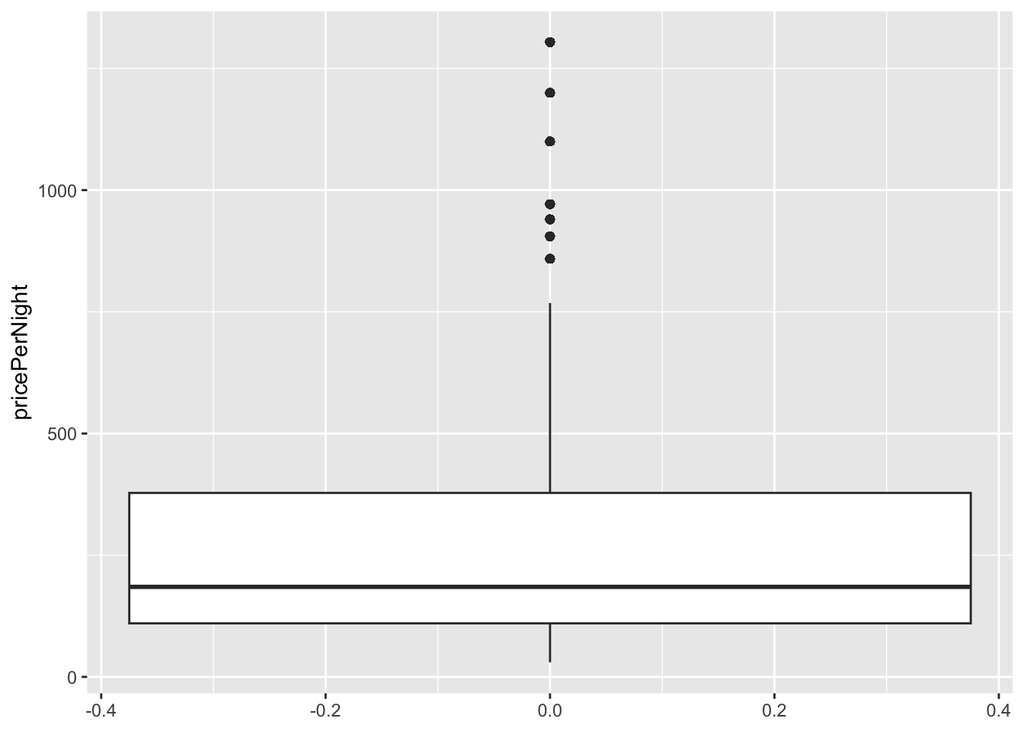

```r
# Price Classification
# Finding the range of values so I can determine the price classification
hotel_price <- read.csv("hotel_prices.csv", na.strings = "Nan")
ggplot(hotel_price, aes(y=pricePerNight)) + geom_boxplot()
```

```r
summary(hotel_price$pricePerNight)
```

```
##    Min. 1st Qu.  Median    Mean 3rd Qu.    Max.
##      30     110     185     277     378    1304
```

```r
# Categorizing the prices
hotel_price <- mutate(hotel_price, priceClass = ifelse(pricePerNight <= 110 , "Low",
                                             ifelse(pricePerNight > 110 &  pricePerNight < 378 , "Medium", "High")))

head(hotel_price)
```

```
##   hotelId                                  hotelName pricePerNight checkInDate
## 1  687463 Robertson Quay Hotel (Staycation Approved)           223  2022-10-26
## 2  687463 Robertson Quay Hotel (Staycation Approved)           223  2022-10-27
## 3  687463 Robertson Quay Hotel (Staycation Approved)           223  2022-10-28
## 4  687463 Robertson Quay Hotel (Staycation Approved)           223  2022-10-29
## 5  687463 Robertson Quay Hotel (Staycation Approved)           223  2022-10-30
## 6  687463 Robertson Quay Hotel (Staycation Approved)           223  2022-10-31
##   checkOutDate priceClass
## 1   2022-10-27     Medium
## 2   2022-10-28     Medium
## 3   2022-10-29     Medium
## 4   2022-10-30     Medium
## 5   2022-10-31     Medium
## 6   2022-11-01     Medium
```

```r
# Day
hotel_price <- mutate(hotel_price, day = weekdays(as.Date(checkInDate)))
head(hotel_price)
```

```
##   hotelId                                  hotelName pricePerNight checkInDate
## 1  687463 Robertson Quay Hotel (Staycation Approved)           223  2022-10-26
## 2  687463 Robertson Quay Hotel (Staycation Approved)           223  2022-10-27
## 3  687463 Robertson Quay Hotel (Staycation Approved)           223  2022-10-28
## 4  687463 Robertson Quay Hotel (Staycation Approved)           223  2022-10-29
## 5  687463 Robertson Quay Hotel (Staycation Approved)           223  2022-10-30
## 6  687463 Robertson Quay Hotel (Staycation Approved)           223  2022-10-31
##   checkOutDate priceClass       day
## 1   2022-10-27     Medium Wednesday
## 2   2022-10-28     Medium  Thursday
## 3   2022-10-29     Medium    Friday
## 4   2022-10-30     Medium  Saturday
## 5   2022-10-31     Medium    Sunday
## 6   2022-11-01     Medium    Monday
```

```r
# Location
master_hotel_id <- read.csv("hotel_master_data_cleaned.csv", na.strings = "Nan")
master_hotel_id < master_hotel_id$hotelId
```

[output not shown]

[output cut: 393 more lines]

```r
balestier <- unique(subset(master_hotel_id, location == "Balestier")$hotelId)
bugis <- unique(subset(master_hotel_id, location == "Bugis")$hotelId)
chinatown <- unique(subset(master_hotel_id, location == "Chinatown")$hotelId)
eastCoast <- unique(subset(master_hotel_id, location == "East Coast")$hotelId)
geylang <- unique(subset(master_hotel_id, location == "Geylang")$hotelId)
habourfront <- unique(subset(master_hotel_id, location == "Harbourfront")$hotelId)
jurong <- unique(subset(master_hotel_id, location == "Jurong")$hotelId)
kallang <- unique(subset(master_hotel_id, location == "Kallang")$hotelId)
lavender <- unique(subset(master_hotel_id, location == "Lavender")$hotelId)
littleIndia <- unique(subset(master_hotel_id, location == "Little India")$hotelId)
marinaBay <- unique(subset(master_hotel_id, location == "Marina Bay")$hotelId)
orchardRoad <- unique(subset(master_hotel_id, location == "Orchard Road")$hotelId)
queenstown <- unique(subset(master_hotel_id, location == "Queenstown")$hotelId)
sentosa <- unique(subset(master_hotel_id, location == "Sentosa Island")$hotelId)
serangoon <- unique(subset(master_hotel_id, location == "Serangoon")$hotelId)
changiAirportRegion <- unique(subset(master_hotel_id, location == "Singapore Changi Airport Region")$hotelId)
sinRiver <- unique(subset(master_hotel_id, location == "Singapore River")$hotelId)
westCoast <- unique(subset(master_hotel_id, location == "West Coast")$hotelId)

hotel_price <- mutate(hotel_price, hotelLocation = ifelse(hotelId %in% balestier, "Balestier",
                    ifelse(hotelId %in% bugis, "Bugis",
                   ifelse(hotelId %in% chinatown, "Chinatown",
                  ifelse(hotelId %in% eastCoast, "East Coast",
                 ifelse(hotelId %in% geylang, "Geylang",
                ifelse(hotelId %in% habourfront, "Harbourfront",
               ifelse(hotelId %in% jurong, "Jurong",
                ifelse(hotelId %in% kallang, "Kallang",
               ifelse(hotelId %in% lavender, "Lavender",
              ifelse(hotelId %in% littleIndia, "Little India",
             ifelse(hotelId %in% marinaBay, "Marina Bay",
              ifelse(hotelId %in% orchardRoad, "Orchard Road",
               ifelse(hotelId %in% queenstown, "Queenstown",
                ifelse(hotelId %in% sentosa, "Sentosa Island",
                 ifelse(hotelId %in% serangoon, "Serangoon",
                  ifelse(hotelId %in% changiAirportRegion, "Singapore Changi Airport Region",
                   ifelse(hotelId %in% sinRiver, "Singapore River",
                    ifelse(hotelId %in% westCoast, "West Coast", "NA")))))))))))))))))))

hotel_price <- hotel_price[!grepl("NA", hotel_price$hotelLocation, fixed = TRUE), ]
head(hotel_price)
```

```
##   hotelId                                  hotelName pricePerNight checkInDate
## 1  687463 Robertson Quay Hotel (Staycation Approved)           223  2022-10-26
## 2  687463 Robertson Quay Hotel (Staycation Approved)           223  2022-10-27
## 3  687463 Robertson Quay Hotel (Staycation Approved)           223  2022-10-28
## 4  687463 Robertson Quay Hotel (Staycation Approved)           223  2022-10-29
## 5  687463 Robertson Quay Hotel (Staycation Approved)           223  2022-10-30
## 6  687463 Robertson Quay Hotel (Staycation Approved)           223  2022-10-31
##   checkOutDate priceClass       day   hotelLocation
## 1   2022-10-27     Medium Wednesday Singapore River
## 2   2022-10-28     Medium  Thursday Singapore River
## 3   2022-10-29     Medium    Friday Singapore River
## 4   2022-10-30     Medium  Saturday Singapore River
## 5   2022-10-31     Medium    Sunday Singapore River
## 6   2022-11-01     Medium    Monday Singapore River
```

```r
# Extract as csv
write.csv(hotel_price,"hotel_price_data_cleaned.csv")
```

**Surrounding Places Of Interest Per Hotel Data**

- After mining the data, we notice that some places of interest are listed as Chinese characters. Hence we googled the terms and replace them. The code is shown below:

```r
df_places_info$placeName[df_places_info$placeName == "新加坡普陀寺"] <- "The Poh Toh Si Temple"
df_places_info$placeName[df_places_info$placeName == "新加坡河驳船游"] <- "Boat Quay "
df_places_info$placeName[df_places_info$placeName == "旋转飞盘（科幻城市）"] <- "Universal Studio Singapore"
df_places_info$placeName[df_places_info$placeName == "海马游乐池"] <- "Adventure Cove Waterpark"
df_places_info$placeName[df_places_info$placeName == "港湾第二大厦"] <- "Imbiah Lookout"
df_places_info$placeName[df_places_info$placeName == "草根书室"] <- "Grassroots Book Room"
```

```r
# Extract as csv
write.csv(df_places_info,"places_of_interest_cleaned.csv")
```

### DATA EXPLORATION

1. Hotel attributes that attracts booking
2. Driving factors determining hotel prices
3. Guest type and their booking behavior

### RECOMMENDER SYSTEM

#### RECOMMENDER SYSTEM: CONTENT BASED

From the Users’ Review, only overall ratings above 4.5 were selected. The assumption is that users who gave these ratings liked the hotel because of the amenities available

```r
# users' reviews dataset
hotelsReviews <- read.csv("workfile_user_review_data.csv")
colnames(hotelsReviews)[1] <- "hotelID"
features_df <- read.csv("amenitiesMatrix.csv")

userProfile <- unique(hotelsReviews)  # double checking no duplicates
userProfile$userId <- NULL
userProfile$content <- NULL
userProfile$checkinDate <- NULL

# find number of unique users in the User Review Data base
uniqueUsers <- unique(userProfile$userId_cleaned)

# select only hotels with ratings of >4.5 Assumption is that users like the amenities offered by these hotels
userProfile <- userProfile %>% filter(ratingAll >4.5)
```

```r
user="_AP359560"

userProfile1 <- userProfile %>% filter(userProfile$userId_cleaned == user)

#extract hotel IDs from UserProfile1, select rows from amentities matrix

userPref <- as.data.frame(NULL)
j <- 1
for(k in userProfile1$hotelID){

  k <- features_df[features_df$HotelID==userProfile1$hotelId[j],]
  #print(t(k))
  j <- j+1
  userPref <- rbind(userPref,k)

}


userPrefMatrix <- userPref[,5:159]
featuresMatrix <- features_df[,5:159]
rownames(featuresMatrix) <- features_df$HotelID
```

The rows in the User Profile are then condensed into a single row to feed into the recommender model later, userTest is now a single line of amenities favoured by the user.

```r
#condenses preferences of user into a single row to feed into recommander model
userTest <- apply(userPrefMatrix,2,sum)
userTest <- as.numeric(userTest)
userTest <- as.data.frame(t(ceiling(userTest/nrow(userPrefMatrix))))
```

To obtain the ‘training data’, the hotels in the User Profile is removed from the amenities matrix

```r
# remove hotel IDs from featursMatrix containing hotel IDs of userPref
j <-1
for(h in userProfile1$hotelID){

  index <- which(rownames(featuresMatrix)==as.character(h))
  featuresMatrix <- featuresMatrix[-c(index),]

  j <- j+1
}
```

A correlation table is then built by performing similarity testing between the userTest and the individual rows in the amenities matrix. The table is then sorted to reveal the top 10 hotels recommended to this particular user.

```r
# hotels info dataset
hotelinfo <- read.csv("hotel_info_list.csv")

# remove duplicates 268 -> 211
hotels <- unique(hotelinfo)


#remove cancellation tag as this is causing some duplicates 211 -> 204
hotels$freeCancelTag <- NULL
hotels <- unique(hotels)



hotelNames <- cbind(hotels$hotelId, hotels$hotelName, hotels$location)
colnames(hotelNames) <- c("hotelID","hotelNames","location")
hotelNames <- as.data.frame(hotelNames)

# remove one more duplicate 204->203
hotelNames <- unique(hotelNames)


# manually filling in missing location data
hotelNames$location[hotelNames$hotelID=="712600"] <- "Chinatown"
hotelNames$location[hotelNames$hotelID=="31212318"] <- "Chinatown"
hotelNames$location[hotelNames$hotelID=="995050"] <- "Chinatown"
hotelNames$location[hotelNames$hotelID=="1359681"] <- "Little India"
hotelNames$location[hotelNames$hotelID=="687572"] <- "Tiong Bahru"
corTable <- data.frame(hotelID=as.character(), corCoeff=as.numeric())


for(r in rownames(featuresMatrix)){
  train <- featuresMatrix[r,] # individual row from featuresMatrix
  corRow <- c(r, cor(as.numeric(train),as.numeric(userTest))) #perform similarity test
  corTable <- rbind(corTable,corRow)
}

# sort corTable
colnames(corTable) <- c("hotelID","corrCoeff")
corTable <- inner_join(corTable,hotelNames)

corTable <- corTable[order(corTable$corrCoeff,decreasing = TRUE),]

print(corTable$hotelNames[1:10])
```

```
##  [1] "Raffles Singapore (Staycation Approved)"
##  [2] "Naumi Hotel Singapore (Staycation Approved)"
##  [3] "Carlton Hotel Singapore (Staycation Approved)"
##  [4] "Grand Park City Hall Singapore"
##  [5] "Peninsula Excelsior Hotel Singapore"
##  [6] "Victoria Hotel, a NuVe Group Collection"
##  [7] "PARKROYAL COLLECTION Marina Bay, Singapore (Staycation Approved)"
##  [8] "Pan Pacific Singapore (Staycation Approved)"
##  [9] "Mandarin Oriental, Singapore (Staycation Approved)"
## [10] "Singapore Marriott Tang Plaza Hotel (Staycation Approved)"
```

#### RECOMMENDER SYSTEM: RATING BASED

Let us create a recommender system to help recommend hotels for users. First, we will need to create the matrix where the user is the row-names and hotels is the col-names.

```r
# Read csv
user_data = read.csv("workfile_user_review_data.csv")
hotel_master_data = read.csv("hotel_master_data_cleaned.csv")

user_id_list = unique(user_data$userId_cleaned)
hotel_id_list = unique(hotel_master_data$hotelId)
hotel_name_list = unique(hotel_master_data$hotelName)


# Create matrix user to hotel id with rating all < This will be the first approach
mat <- matrix(0,
              ncol = length(hotel_id_list),
              nrow = length(user_id_list)
              )
colnames(mat) <- hotel_id_list
rownames(mat) <- user_id_list

for(i in 1:nrow(user_data)){
 hotel_index =  which(hotel_id_list == user_data[i,]$hotelId )
 user_index = which(user_id_list == user_data[i,]$userId_cleaned)
 mat[user_index,hotel_index] <- user_data[i,]$ratingAll
}

mat[mat==0] <- NA
```

We can further reduce the dimensions by removing hotels that have no ratings at all. We can effectively reduce the column size from 203 to 189 hotels.

Lastly, we will need to shuffle the matrix so that when we split the matrix to test and train matrix, it will not introduce any bias.

```r
# Create another matrix but this time with reduced dimensions, we will reduce the number of users.
no_of_NAs <- rowSums(is.na(mat))
no_of_Reviews <- 203 - rowSums(is.na(mat))
no_of_Reviews <- as.data.frame(no_of_Reviews)

# if we go for >2 there will be 932 records , >3 = 446, >4 = 257 , > 5 = 151
length(no_of_Reviews[no_of_Reviews$no_of_Reviews > 3,]) # 151
```

```
## [1] 446
```

```r
no_of_Reviews_vector <- as.vector(no_of_Reviews)
no_of_Reviews_vector <- no_of_Reviews_vector$no_of_Reviews
no_of_Reviews_vector <- no_of_Reviews_vector > 3

mat_reduced <- mat[no_of_Reviews_vector,]
nrow(mat_reduced)
```

```
## [1] 446
```

```r
# Shuffle the matrix
set.seed(41)
shuffle <- sample(nrow(mat))
shuffle2 <- sample(nrow(mat_reduced))
mat <- mat[shuffle,]
mat_reduced <- mat_reduced[shuffle2, ]
colnames(mat) <- hotel_name_list
colnames(mat_reduced) <- hotel_name_list

# for mat reduced, we can futher reduce by removing hotels with no ratings
ncol(mat_reduced)
```

```
## [1] 203
```

```r
mat_reduced <- mat_reduced[ , -which( colSums(is.na(mat_reduced)) == nrow(mat_reduced)) ]
ncol(mat_reduced) # 189 hotels left
```

```
## [1] 189
```

We will now create test and train matrix, by taking the first 10 users to be test while the rest is used for training the model. We will also need to convert the data to realRatingMatrix so that it can be used by the recommenderLab package.

```r
test <- mat[1:10,]
train <- mat[11:nrow(mat),]

test2 <- mat_reduced[1:10,]
train2 <- mat_reduced[11:nrow(mat_reduced),]

# convert to realRatingMatrix format
mat_data <- mat %>% as("matrix")  %>% as("realRatingMatrix")
test <- test %>% as("matrix")  %>% as("realRatingMatrix")
train <- train %>% as("matrix")  %>% as("realRatingMatrix")

mat_reduced_data <- mat_reduced %>% as("matrix")  %>% as("realRatingMatrix")
test2 <- test2 %>% as("matrix")  %>% as("realRatingMatrix")
train2 <- train2 %>% as("matrix")  %>% as("realRatingMatrix")
```

Now we can perform the actual modelling. We will be creating 4 different models, the RANDOM, IBCF, SVD and POPULAR. We have skipped out on UBCF in favor of IBCF because IBCF works better in our case. A hotel will always be the same hotel - it doesn’t change. User’s preference for hotels may change. Also, there are much fewer hotels than users, meaning less computation to perform and faster results.

The output is a list of hotels recommended for the test users.

Based on the output, it would seem that SVD and POPULAR has recommended the same few hotels to the same group of people. This leads us to question the reliability of the results from SVD and POPULAR as it does not provide meaningful recommendations for our users.

Based on the results, only RANDOM and IBCF provided recommendations which were unique to each user. We can dig deeper into the performance of these two models.

```r
model <- Recommender(train2, method = "RANDOM")
RANDOM_recommendations <- predict(model, test2, n=3)
RANDOM_recommendations %>% as("list")
```

```
## $`0`
## [1] "Fragrance Hotel - Kovan (SG Clean) (Staycation Approved)"
## [2] "Hotel Mi Singapore"
## [3] "Oasia Hotel Downtown, Singapore by Far East Hospitality  (Staycation Approved)"
##
## $`1`
## [1] "Fragrance Hotel - Ocean View (Staycation Approved)"
## [2] "The Daulat by Hotel Calmo"
## [3] "Grand Copthorne Waterfront Singapore"
##
## $`2`
## [1] "Hotel 81 Balestier (Staycation Approved)"
## [2] "Vintage Inn @ Clarke Quay Singapore(SG Clean)"
## [3] "Fragrance Rose Singapore(SG Clean) (Staycation Approved)"
##
## $`3`
## [1] "Lion Peak Hotel Bugis (SG Clean, Staycation Approved)"
## [2] "Oasia Resort Sentosa by Far East Hospitality"
## [3] "Siloso Beach Resort Sentosa Singapore  (Staycation Approved)"
##
## $`4`
## [1] "Hotel Calmo Chinatown"
## [2] "Amara Singapore (Staycation Approved)"
## [3] "Hotel 81 Kovan Singapore (Staycation Approved)"
##
## $`5`
## [1] "Hotel Boss Singapore (Staycation Approved)"
## [2] "Hotel Fort Canning Singapore (Staycation Approved)"
## [3] "Fragrance Hotel - Kovan (SG Clean) (Staycation Approved)"
##
## $`6`
## [1] "The Great Madras by Hotel Calmo"
## [2] "New Cape Inn (Staycation Approved)"
## [3] "Days Hotel by Wyndham Singapore At Zhongshan Park (SG Clean)"
##
## $`7`
## [1] "Hotel 81 Dickson Singapore (Staycation Approved)"
## [2] "D'Resort @ Downtown East"
## [3] "Orchard Hotel Singapore (Staycation Approved)"
##
## $`8`
## [1] "Ascott Raffles Place Singapore (SG Clean)"
## [2] "Hotel Fort Canning Singapore (Staycation Approved)"
## [3] "Hotel Clover the Arts (Staycation Approved)"
##
## $`9`
## [1] "Dusit Thani Laguna Singapore (Staycation Approved)"
## [2] "Ji Hotel Orchard Singapore (Staycation Approved)"
## [3] "Village Hotel Bugis by Far East Hospitality (Staycation Approved)"
```

```r
model2 <- Recommender(train2, method = "IBCF")
IBCF_recommendations <- predict(model2, test2, n=10)
IBCF_recommendations %>% as("list")
```

```
## $`0`
##  [1] "Naumi Hotel Singapore (Staycation Approved)"
##  [2] "Carlton Hotel Singapore (Staycation Approved)"
##  [3] "Grand Park City Hall Singapore"
##  [4] "Peninsula Excelsior Hotel Singapore"
##  [5] "PARKROYAL COLLECTION Marina Bay, Singapore (Staycation Approved)"
##  [6] "lyf Funan Singapore (Staycation Approved)"
##  [7] "Orchard Hotel Singapore (Staycation Approved)"
##  [8] "Hilton Singapore Orchard (SG Clean)"
##  [9] "Hotel Yan Singapore (Staycation Approved)"
## [10] "Hotel Mi Singapore"
##
## $`1`
##  [1] "Hotel Yan Singapore (Staycation Approved)"
##  [2] "Studio M Hotel"
```

[output cut: 104 more lines]

```r
model3 <- Recommender(train2, method = "SVD")
SVD_recommendations <- predict(model3, test2, n=10)
SVD_recommendations %>% as("list")
```

```
## $`0`
##  [1] "Fragrance Hotel - Oasis(SG Clean) (Staycation Approved)"
##  [2] "Resorts World Sentosa - Equarius Villas"
##  [3] "K Hotel Aliwal (Premier)"
##  [4] "Beat.Capsules Hostel@Boat Quay"
##  [5] "Rucksack Inn @ Tyrwhitt"
##  [6] "Hotel Clover the Arts (Staycation Approved)"
##  [7] "Crowne Plaza Changi Airport Singapore (Staycation Approved)"
##  [8] "Rucksack Inn @ Temple Street"
##  [9] "PARKROYAL COLLECTION Marina Bay, Singapore (Staycation Approved)"
## [10] "voco Orchard Singapore, an IHG hotel"
##
## $`1`
##  [1] "Fragrance Hotel - Oasis(SG Clean) (Staycation Approved)"
##  [2] "Resorts World Sentosa - Equarius Villas"
```

[output cut: 104 more lines]

```r
model4 <- Recommender(train2, method = "POPULAR")
POP_recommendations <- predict(model4, test2, n=10)
POP_recommendations %>% as("list")
```

```
## $`_FB467382`
##  [1] "The Ritz-Carlton, Millenia Singapore (Staycation Approved)"
##  [2] "Goodwood Park Hotel (Staycation Approved)"
##  [3] "Yotel Singapore Orchard Road (Staycation Approved)"
##  [4] "Capri by Fraser, China Square / Singapore (SG Clean)"
##  [5] "Five/6 Hotel Splendour (Staycation Approved)"
##  [6] "Peninsula Excelsior Hotel Singapore"
##  [7] "Four Seasons Hotel Singapore (Staycation Approved)"
##  [8] "Conrad Centennial Singapore (Staycation Approved)"
##  [9] "Grand Park City Hall Singapore"
## [10] "PARKROYAL COLLECTION Marina Bay, Singapore (Staycation Approved)"
##
## $`_GG478658`
##  [1] "The Ritz-Carlton, Millenia Singapore (Staycation Approved)"
##  [2] "Goodwood Park Hotel (Staycation Approved)"
```

[output cut: 104 more lines]

To understand the performance of our recommender systems, we will need to evaluate the effectiveness of the models through cross validation. Below is the ROC curve plotted for all 4 different models. We can see that IBCF performed the best compared to the other 3 models. With SVD and Random performing the worst. At FPR at 0.05, IBCF returned about 0.15 TPR, which is the best result compared to other models.

```r
# Next up : Evaluation

#multiple algorithms
#POPULAR based on item popularity
set.seed(15) # 7 15
scheme = evaluationScheme(mat_reduced_data, method="cross-validation",
                           k=4, given=-1, goodRating=5)
algorithms = list(
  "popular items" = list(name="POPULAR"),
  "item-based CF" = list(name="IBCF"),
  "SVD" = list(name="SVD"),
  "RANDOM" = list(name="RANDOM")
)

results = evaluate(scheme, method=algorithms, type="topNList", n=c(1,3,5,10,15,20))
```

```
## POPULAR run fold/sample [model time/prediction time]
##   1  [0.001sec/0.045sec]
##   2  [0sec/0.029sec]
##   3  [0.001sec/0.033sec]
##   4  [0.001sec/0.026sec]
## IBCF run fold/sample [model time/prediction time]
##   1  [0.03sec/0.007sec]
##   2  [0.011sec/0.006sec]
##   3  [0.012sec/0.005sec]
##   4  [0.011sec/0.012sec]
## SVD run fold/sample [model time/prediction time]
##   1  [0.006sec/0.007sec]
##   2  [0.006sec/0.007sec]
##   3  [0.007sec/0.007sec]
##   4  [0.005sec/0.008sec]
## RANDOM run fold/sample [model time/prediction time]
##   1  [0sec/0.006sec]
##   2  [0sec/0.006sec]
##   3  [0sec/0.007sec]
##   4  [0sec/0.006sec]
```

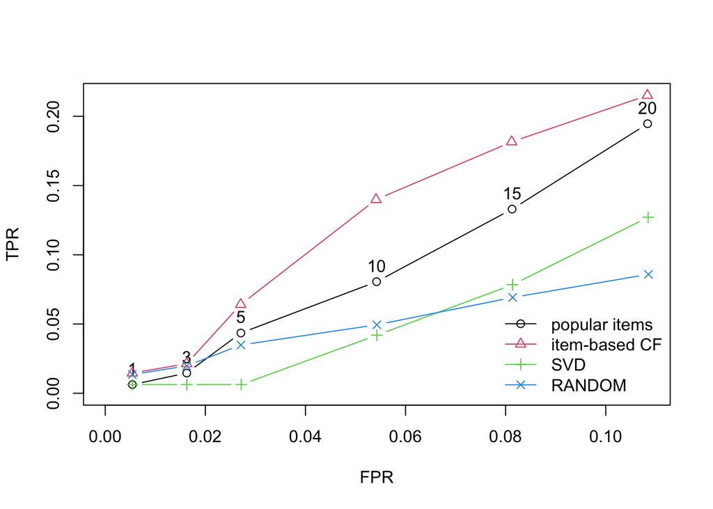

```r
plot(results, annotate=T)
```

We can also find the prediction accuracy using the RMSE, MSE and MAE results. Based on the results, RANDOM had the worst RMSE MSE and MAE scores followed by IBCF. SVD and POPULAR produced similar results. But as we recall, both models produced the same recommendation for all users and is deemed unmeaningful, hence IBCF is the best out of all the models.

```r
# error data
set.seed(15)
ev = evaluationScheme(mat_reduced_data, method="split",train=0.9, given=-1, goodRating=5)

r1 = Recommender(getData(ev, "train"), method = "SVD")
r2 = Recommender(getData(ev, "train"), method = "IBCF")
r3 = Recommender(getData(ev, "train"), method = "POPULAR")
r4 = Recommender(getData(ev, "train"), method = "RANDOM")
p1 = predict(r1, getData(ev, "known"), type="ratings")
p2 = predict(r2, getData(ev, "known"), type="ratings")
p3 = predict(r3, getData(ev, "known"), type="ratings")
p4 = predict(r4, getData(ev, "known"), type="ratings")

error = rbind(
  SVD = calcPredictionAccuracy(p1, getData(ev, "unknown")),
  IBCF = calcPredictionAccuracy(p2, getData(ev, "unknown")),
  POPULAR = calcPredictionAccuracy(p3, getData(ev, "unknown")),
  RANDOM = calcPredictionAccuracy(p4, getData(ev, "unknown"))
)
error
```

```
##              RMSE       MSE       MAE
## SVD     0.7822336 0.6118895 0.6455975
## IBCF    0.9885432 0.9772176 0.7244956
## POPULAR 0.7751015 0.6007823 0.6445663
## RANDOM  1.6067840 2.5817547 1.4152146
```

Since we have came to the conclusion that IBCF performed the best out of the 4 models, we can dive deeper to analyse the Precision Recall score for the IBCF. Based on the results, while the precision recall for the first recommendation had poor results, subsequent recommendations performed relatively better. With the highest recall score being 0.35.

```r
set.seed(15)
scheme1 = evaluationScheme(mat_reduced_data, method="cross-validation", k=4, given=-1, goodRating=5)
results1 = evaluate(scheme1, method="IBCF", type="topNList", n=c(1,3,5,10,15,20))
```

```
## IBCF run fold/sample [model time/prediction time]
##   1  [0.011sec/0.007sec]
##   2  [0.018sec/0.006sec]
##   3  [0.012sec/0.006sec]
##   4  [0.011sec/0.006sec]
```

```r
#generate the confusion matrix
getConfusionMatrix(results1)[[1]]
```

```
##               TP        FP        FN       TN        N   precision     recall
## [1,] 0.000000000  1.000000 0.3274336 182.9912 184.3186 0.000000000 0.00000000
## [2,] 0.008849558  2.991150 0.3185841 181.0000 184.3186 0.002949853 0.02702703
## [3,] 0.017699115  4.982301 0.3097345 179.0088 184.3186 0.003539823 0.05405405
## [4,] 0.070796460  9.929204 0.2566372 174.0619 184.3186 0.007079646 0.21621622
## [5,] 0.097345133 14.902655 0.2300885 169.0885 184.3186 0.006489676 0.29729730
## [6,] 0.115044248 19.884956 0.2123894 164.1062 184.3186 0.005752212 0.35135135
##             TPR         FPR  n
## [1,] 0.00000000 0.005435772  1
## [2,] 0.02702703 0.016259481  3
## [3,] 0.05405405 0.027083189  5
## [4,] 0.21621622 0.053973732 10
## [5,] 0.29729730 0.081007768 15
## [6,] 0.35135135 0.108090169 20
```